# Generalized Jeffreys’s Approximate Objective Bayes Factor

Part Four: One-Way Analysis of Variance

============================================================================================================

Open Science Framework: https://osf.io/qeprj/

## 0. Getting Started

| Source | Sum of Squares | Degrees of Freedom | Mean Square | $F$-Ratio |
| --- | --- | --- | --- | --- |
| Conditions | $\textit{SS}_{\ \text{between}}$ | $a-1$ | $\textit{MS}_{\ \text{between}}$ | $\frac{ \textit{MS}_{\ \text{between}}}{\textit{MS}_{\ \text{within}}}$ |
| Error | $\textit{SS}_{\ \text{within}}$ | $N-a$ | $\textit{MS}_{\ \text{within}}$ |  |
| Total | $\textit{SS}_{\ \text{total}}$ | $N-1$ |  |  |

The condition (between-groups) sum of squares is $\textit{SS}_{\ \text{between}}=\sum_{i=1}^a n_i\left(\bar{Y}_{i\centerdot}-\bar{Y}_{\centerdot\centerdot}\right)^2=\sum_{i=1}^a n_i\bar{Y}_{i\centerdot}^2-N\bar{Y}_{\centerdot\centerdot}^2$

The error (within-groups) sum of squares is $\textit{SS}_{\ \text{within}}=\sum_{i=1}^a\sum_{j=1}^{n_i}\left(Y_{ij}-\bar{Y}_{i\centerdot}\right)^2$

The total sum of squares is $\textit{SS}_{\ \text{total}}=\sum_{i=1}^a\sum_{j=1}^{n_i}\left(Y_{ij}-\bar{Y}_{\centerdot\centerdot}\right)^2=\sum_{i=1}^a\sum_{j=1}^{n_i} Y_{ij}^2-N\bar{Y}_{\centerdot\centerdot}^2$

The total number of observations is $N=\sum_{i=1}^a n_i$

The grand mean is $\bar{Y}_{\centerdot\centerdot}=\frac{1}{N}\sum_{i=1}^a\sum_{j=1}^{n_i} Y_{ij}$

The condition means are $\bar{Y}_{i\centerdot}=\frac{1}{n_i}\sum_{j=1}^{n_i} Y_{ij}$

## 1. Methods

### “*BayesFactor*” R Package

**Exploratory** hypothesis testing: $\mathcal{H_0}:\mu_1=\dotsb=\mu_a$ versus $\mathcal{H_1}:$ not all means are equal, assuming fixed effects.

$\hspace{12.43em}\mathcal{H_0}:\sigma_t^2=0$ versus $\mathcal{H_1}:\sigma_t^2\neq0$, assuming random effects.

Reparametrization $\mu_i=\mu+t_i=\mu+\sigma_\epsilon d_i$ with $\sum_{i=1}^a d_i=0$

$$\begin{align} \tag{1}
\mathcal{M}_1:\ Y_{ij}&=\mu+\sigma_\epsilon d_i+\epsilon_{ij}\\
\text{versus}\quad\mathcal{M}_0:\ Y_{ij}&=\mu+\epsilon_{ij},\\
\qquad\qquad&\epsilon_{ij}\overset{\text{i.i.d.}}{\sim}\mathcal{N}(0,\sigma_\epsilon^2)\quad\text{
for condition } i=1,\dotsb,a;\text{ (unbalanced) subject }
j=1,\dotsb,n_i
\end{align}$$

$$\begin{equation} \tag{2}
\pi(\mu,\sigma_\epsilon^2)\propto 1/\ \sigma_\epsilon^{2}
\end{equation}$$

$$\begin{equation} \tag{3}
d_i^\star\mid g\overset{\text{i.i.d.}}{\sim}\mathcal{N}(0,g)
\end{equation}$$

$$\begin{equation} \tag{4}
g\sim\text{Scale-inv-}\chi^2(1,h^2)
\end{equation}$$

$$\begin{equation} \tag{5}
(d_1^\star,\dotsb,d_{a-1}^\star)=(d_1,\dotsb,d_a)\cdot\mathbf{Q}
\end{equation}$$

$$\begin{equation} \tag{6}
\mathbf{I}_a-\frac{1}{a}\mathbf{J}_a=\mathbf{Q}\cdot\mathbf{Q}^\top
\end{equation}$$

By default, $h=0.5$ for the fixed effects (in this case) and $h=1$ for the random effects in Eq. 4.

$\mathbf{Q}$ is an $a\times(a-1)$ matrix of the $a-1$ eigenvectors of unit length corresponding to the nonzero eigenvalues of the left side term in Eq. 6.  
For example, when $a=3$, the projected standardized effects are

$$(d_1^\star,\ d_2^\star)=(d_1,\ d_2,\ d_3)\cdot
\begin{pmatrix}
\frac{\sqrt{6}}{3} & 0 \\
-\frac{\sqrt{6}}{6} & \frac{\sqrt{2}}{2} \\
-\frac{\sqrt{6}}{6} & -\frac{\sqrt{2}}{2}
\end{pmatrix}$$

In the other direction (given $d_1+d_2+d_3=0$),

$$(d_1,\ d_2,\ d_3)^\top=
\begin{pmatrix}
\frac{\sqrt{6}}{3} & 0 \\
-\frac{\sqrt{6}}{6} & \frac{\sqrt{2}}{2} \\
-\frac{\sqrt{6}}{6} & -\frac{\sqrt{2}}{2}
\end{pmatrix}\cdot(d_1^\star,\ d_2^\star)^\top$$

Read more: https://rpubs.com/sherloconan/1070217.

```r
computeQ <- function(a) {
  #' Implement Eq. 6
  S <- diag(a) - matrix(1, nrow=a, ncol=a) / a
  e <- qr(S)
  Q <- qr.Q(e) %*% diag(sign(diag(qr.R(e))))
  Q[, which(abs(e$qraux) > 1e-3), drop=F]
}
computeQ(3)
```

```
##            [,1]          [,2]
## [1,]  0.8164966  3.732125e-17
## [2,] -0.4082483  7.071068e-01
## [3,] -0.4082483 -7.071068e-01
```

The Jeffreys–Zellner–Siow (JZS) Bayes factor for the Bayesian **balanced** one-way (between-subjects) analysis of variance (ANOVA) is computed by integrating across one dimension in Eq. 7 (corrigendum; Morey et al., [2011](https://doi.org/10.1016/j.jmp.2011.06.004), p. 374). $n_i=n$ for all $i$.

$$\begin{equation} \tag{7}
\textit{JZS-BF}_{10}=(2\pi)^{-\frac{1}{2}}h\cdot\int_0^\infty(1+ng)^{\frac{a(n-1)}{2}}\left(1+\frac{ng}{1+\frac{a-1}{a(n-1)}\cdot
F}\right)^{-\frac{an-1}{2}}g^{-\frac{3}{2}}e^{-\frac{h^2}{2g}}\text{d}g,
\end{equation}$$

```r
JZS2BF10 <- function(h=0.5, n, a, F_ratio) {
  #' Input -
  #' h:            the prior scale on the variability of fixed effects, i.e.,
  #'               `rscale="medium"` or `rscale=1/sqrt(2)` in BayesFactor::ttestBF, or
  #'               `rscaleFixed="medium"` or `rscaleFixed=0.5` in BayesFactor::anovaBF
  #' n:            number of observations per balanced group
  #' a:            number of groups
  #' F_ratio:      F-ratio
  #' Output - the JZS Bayes factor for balanced one-way ANOVA claimed in Eq. 7

  coef <- (2*pi)^(-0.5) * h
  integrand <- function(g) {
    K <- 1 + n*g / (1 + F_ratio * (a-1)/(a*n-a))
    (1+n*g)^((a*n-a)/2) * K^((1-a*n)/2) * g^(-1.5) * exp(-h^2/(2*g))
  }
  unname(coef * integrate(integrand, lower=0, upper=Inf)$value)
}

test <- aov(weight ~ group, PlantGrowth) # one-way ANOVA with three balanced groups, n = 10
F_ratio <- summary(test)[[1]]["group", "F value"] # F-ratio

## https://forum.cogsci.nl/discussion/9448/verifying-jzs-bayes-factor-for-one-way-anova
JZS2BF10(n=10, a=3, F_ratio=F_ratio) # verifying Eq. 7
```

```
## [1] 3.896995
```

```r
BayesFactor::anovaBF(weight ~ group, PlantGrowth, progress=F) # testing fixed effects
```

```
## Bayes factor analysis
## --------------
## [1] group : 3.896995 ±0.01%
##
## Against denominator:
##   Intercept only
## ---
## Bayes factor type: BFlinearModel, JZS
```

Fixed or Random Effects

```r
BayesFactor::anovaBF(weight ~ group, PlantGrowth, whichRandom="group", progress=F) # testing random effects
```

```
## Bayes factor analysis
## --------------
## [1] group : 3.060886 ±0%
##
## Against denominator:
##   Intercept only
## ---
## Bayes factor type: BFlinearModel, JZS
```

Fixed effects - assumed to be constant for all trials

Random effects - a subset of the entire population of treatments

```r
fit1_fixed <- lm(weight ~ group, PlantGrowth)
fit0_fixed <- lm(weight ~ 1, PlantGrowth)
anova(fit1_fixed, fit0_fixed) # testing fixed effects
```

```
## Analysis of Variance Table
##
## Model 1: weight ~ group
## Model 2: weight ~ 1
##   Res.Df    RSS Df Sum of Sq      F  Pr(>F)
## 1     27 10.492
## 2     29 14.258 -2   -3.7663 4.8461 0.01591 *
## ---
## Signif. codes:  0 '***' 0.001 '**' 0.01 '*' 0.05 '.' 0.1 ' ' 1
```

```r
summary(test)
```

```
##             Df Sum Sq Mean Sq F value Pr(>F)
## group        2  3.766  1.8832   4.846 0.0159 *
## Residuals   27 10.492  0.3886
## ---
## Signif. codes:  0 '***' 0.001 '**' 0.01 '*' 0.05 '.' 0.1 ' ' 1
```

```r
fit1_rand <- nlme::lme(weight ~ 1, PlantGrowth, ~1 | group, method="ML")
fit0_rand <- nlme::gls(weight ~ 1, PlantGrowth, method="ML") # if `REML`, same as fit0_fixed
anova(fit1_rand, fit0_rand) # testing random effects
```

```
##           Model df      AIC      BIC    logLik   Test  L.Ratio p-value
## fit1_rand     1  3 66.29798 70.50157 -30.14899
## fit0_rand     2  2 66.82084 69.62323 -31.41042 1 vs 2 2.522865  0.1122
```

scroll to top

### BIC Approximation

Approximating Bayes Factors from Bayesian Information Criterion (BIC)

The BIC for model $i$ with the number of free parameters $k_i$ and the sample size $N$ is $\text{BIC}(\mathcal{M}_i)=-2\ln{\mathcal{L}_i}+k_i\ln{N}\quad$ for $N\gg k_i$,

where $\mathcal{L}_i=p(\boldsymbol{y}\mid\hat{\boldsymbol{\theta}}_i,\mathcal{M}_i)$ is the maximum likelihood.

Use the second-order Taylor approximation of log-marginal likelihood of each model.

$$\begin{equation} \tag{8}
\mathit{BF}_{10}\approx\exp\left\{\frac{\text{BIC}(\mathcal{M}_0)-\text{BIC}(\mathcal{M}_1)}{2}\right\}
\end{equation}$$

Derivation in Wagenmakers ([2007](https://dx.doi.org/10.3758/BF03194105), Appendix B).

```r
## https://github.com/tomfaulkenberry/anovaBFcalc/blob/master/R/bf_bic.R
df1 <- 2; df2 <- 27; N <- df1 + df2 + 1 # total number of observations
sqrt(N^df1 * (1 + F_ratio * df1 / df2)^(-N)) # BF₀₁
```

```
## [1] 0.3012838
```

```r
null <- aov(weight ~ 1, PlantGrowth) # null model fit
exp((BIC(test) - BIC(null)) / 2) # same BF₀₁
```

```
## [1] 0.3012838
```

scroll to top

### Approximate Bayes Factor

$$\begin{align}
\text{BIC}(\mathcal{M}_1)-\text{BIC}(\mathcal{M}_0)&=-2\ln{\mathcal{L}_1}+k_1\ln{N}+2\ln{\mathcal{L}_0}-k_0\ln{N}
\\
&=-2(\ln{\mathcal{L}_1}-\ln{\mathcal{L}_0})+(k_1-k_0)\ln{N} \\
&=-\Lambda+(k_1-k_0)\ln{N} \\
\\
\mathit{BF}_{01}&\approx\exp\left\{\frac{\text{BIC}(\mathcal{M}_1)-\text{BIC}(\mathcal{M}_0)}{2}\right\}
\\
&=\exp\left\{\frac{-\Lambda+(k_1-k_0)\ln{N}}{2}\right\} \\
&=N^{\frac{k_1-k_0}{2}}\!\cdot\exp\left\{-\frac{\Lambda}{2}\right\}
\tag{$8^\prime$}
\end{align}$$

$\mathcal{M}_1:\quad Y_{ij}=\beta_0+\mathbf{x}_{i}^\top\boldsymbol{\theta}+\epsilon_{ij},\qquad\epsilon_{ij}\overset{\text{i.i.d.}}{\sim}\mathcal{N}(0,\sigma_\epsilon^2)\quad\text{ for condition } i=1,\dotsb,a;\text{ (unbalanced) subject } j=1,\dotsb,n_i$ Review

The Wald test statistic is $\ W=(\hat{\boldsymbol{\theta}}-\boldsymbol{\theta}_0)^\top\cdot I(\hat{\boldsymbol{\theta}})\cdot(\hat{\boldsymbol{\theta}}-\boldsymbol{\theta}_0)\mathrel{\dot\sim}\chi_{q}^2\$ under $\mathcal{H}_0$, where $q=a-1$ is the number of parameters in $\boldsymbol{\theta}$.

The likelihood-ratio test statistic is $\ \Lambda:=-2(\ln{\mathcal{L}_0}-\ln{\mathcal{L}_1})\mathrel{\dot\sim}\chi_{k_1-k_0}^2\$ under $\mathcal{H}_0$.  
In some contexts, $\lambda_{\text{LR}}$ refers to the likelihood-ratio test statistic, while $\Lambda$ represents the likelihood ratio $\mathcal{L}_0/\mathcal{L}_1\in[0,1]$.

- If we plug in $\Lambda$ instead of $W$, the JAB becomes **identical** to the BIC approximation.
- Otherwise, the JAB is asymptotically equivalent to the BIC approximation since $\lvert W-\Lambda\rvert\overset{p}{\to}0$ under $\mathcal{H}_0$, as $N\to\infty$.
- $k_1-k_0=a-1$ in a one-way ANOVA with $a$ conditions. $\Lambda\equiv N\cdot\ln{\left(1+\frac{a-1}{N-a}\cdot F\right)}=(a-1)\cdot\ln{\left(1+\frac{F}{(N-a)\ /\ (a-1)}\right)^{N\ /\ (a-1)}}\to(a-1)\cdot F\quad$ as $N\to\infty$. [Derivation](http://users.stat.umn.edu/~sandy/courses/8311/handouts/nlme.pdf)

```r
null <- aov(weight ~ 1, PlantGrowth)
LRS <- -2 * (logLik(null) - logLik(test))
derivFS <- 30 * log(1 + F_ratio * (3-1) / (30-3))
WS <- t(coef(test)[-1]) %*% solve(vcov(test)[-1,-1]) %*% coef(test)[-1]

cat("The likelihood-ratio test statistic is", LRS, "and", derivFS, "(based on F(2,27))",
    "\nThe Wald test statistic is", WS, "and", (3-1)*F_ratio, "(based on F(2,27))")
```

```
## The likelihood-ratio test statistic is 9.2018 and 9.2018 (based on F(2,27))
## The Wald test statistic is 9.692176 and 9.692176 (based on F(2,27))
```

Test on a Single Parameter

The test statistic in a Wald test is $W=\left(\frac{\hat{\theta}-\theta_0}{\text{se}(\hat{\theta})}\right)^2\sim\chi_1^2$ under $\mathcal{H}_0$, where $\hat{\theta}$ is the maximum likelihood estimate, and $\text{se}(\hat{\theta})$ is the standard error.

Wagenmakers ([2022](https://doi.org/10.31234/osf.io/egydq); its Eq. 6) reviewed the Jeffreys-style approximate Bayes factor (JAB) and proposed a piecewise approximation (WAB) from $p$-value and effective sample size $N$ in Eq. 10.

The complication with JAB is that the approximation is valid **only** when $\text{se}(\hat{\theta})\ll\sigma_g$, where $\sigma_g$ is the scale of the prior distribution $g(\theta)$. Note that with very small sample sizes, this assumption is not true and Eq. 9 is biased against $\mathcal{H}_0$.

$$\begin{equation} \tag{9}
\textit{JAB}_{01}=A\cdot\sqrt{N}\exp\left\{-\frac{1}{2}W\right\}
\end{equation}$$

A normal unit-information prior for $\theta$ yields $A=1$. Based on the Jeffreys prior, the general approximation specifies $A=\sqrt{\pi/2}\approx1.253$.

Wagenmakers’s piecewise approximation is

$$\textit{WAB}_{01}\approx
\begin{cases} \tag{10}
\text{$\ p^{\frac{1}{4}}\sqrt{N}$,} & \text{$p>0.5$} \\
\\
\text{$\ \sqrt{pN}$,} & \text{$0.1<p\leqslant0.5$ (simpler)} \\
\\
\text{$\ \frac{4}{3}p^{\frac{2}{3}}\sqrt{N}$,} &
\text{$0.1<p\leqslant0.5$ (more precise)} \\
\\
\text{$\ 3p\sqrt{N}$,} & \text{$p\leqslant0.1$}
\end{cases}$$

Asymptotics 101

PDF $f_Y(y_i;\boldsymbol{\theta})$, joint likelihood $L(\boldsymbol{\theta};\boldsymbol{y})$, log likelihood $l(\boldsymbol{\theta};\boldsymbol{y})$, score $l^\prime(\boldsymbol{\theta};\boldsymbol{y})$

While $f(y_i\mid\boldsymbol{\theta})$ and $f(y_i;\boldsymbol{\theta})$ can represent the same mathematical relationship, the notation signals different interpretations and emphases in statistical analysis.

The expected Fisher information matrix, evaluated at $\boldsymbol{\theta}_0$, is $\left[\ \mathcal{I}(\boldsymbol{\theta}_0)\ \right]_{ij}:=\mathbb{E}\left[\left(\frac{\partial}{\partial\theta_i}\ln{f(Y;\boldsymbol{\theta})}\right)\left(\frac{\partial}{\partial\theta_j}\ln{f(Y;\boldsymbol{\theta})}\right)\ \bigg|\ \boldsymbol{\theta}_0\right]$.

Under certain [regularity conditions](https://en.wikipedia.org/wiki/Fisher_information#Regularity_conditions), it is easier to compute $\left[\ \mathcal{I}(\boldsymbol{\theta}_0)\ \right]_{ij}=-\mathbb{E}\left[\left(\frac{\partial^2}{\partial\theta_i\partial\theta_j}\ln{f(Y;\boldsymbol{\theta})}\right)\ \bigg|\ \boldsymbol{\theta}_0\right]$.

The observed Fisher information matrix is denoted as $\left[\ I(\hat{\boldsymbol{\theta}})\ \right]_{ij}$.

scroll to top

### Extended JAB

We obtained unexpected results from the BIC approximation-based methods in a one-way ANOVA, specifically when the number of groups is relatively large (e.g., up to five).

In the analysis below, the $p$-value is around 0.04, and the *anovaBF* function returns a value around 1. However, the BIC approximation yields an extreme value of 143 in favor of the null hypothesis.

```r
n <- 30        # number of observations per balanced group
a <- 5         # number of groups
m1 <- 0        # population mean of the first group (suppose the lowest)
delta <- 0.3   # evenly-spaced population mean difference, m2 - m1 = m3 - m2  = ···

set.seed(277)
data <- data.frame("resp" = rnorm(n * a, m1 + delta * (1:a - 1), 1),
                   "grp" = rep(paste0("grp", 1:a), n), stringsAsFactors=T)
summary(fit51 <- aov(resp ~ grp, data)) # full model fit
```

```
##              Df Sum Sq Mean Sq F value Pr(>F)
## grp           4  10.03  2.5078    2.53 0.0431 *
## Residuals   145 143.74  0.9913
## ---
## Signif. codes:  0 '***' 0.001 '**' 0.01 '*' 0.05 '.' 0.1 ' ' 1
```

```r
FVal <- summary(fit51)[[1]]["grp", "F value"] # F-ratio

1 / BayesFactor::anovaBF(resp ~ grp, data, progress=F) # JZS-BF₀₁
```

```
## Bayes factor analysis
## --------------
## [1] Intercept only : 1.13705 ±0%
##
## Against denominator:
##   resp ~ grp
## ---
## Bayes factor type: BFlinearModel, JZS
```

```r
# BIC approximation
fit50 <- aov(resp ~ 1, data)       # null model fit
exp((BIC(fit51) - BIC(fit50)) / 2) # BIC-BF₀₁
```

```
## [1] 142.8294
```

```r
# Jeffreys approximate Bayes factor (Λ → (a-1)⋅F)
(n*a)^((a-1)/2) * exp(-0.5 * (a-1) * FVal) # original JAB₀₁
```

```
## [1] 142.8158
```

```r
sqrt(n*a) * exp(-0.5 * (a-1) * FVal * ((n*a)^(1/(a-1))-1) / (n*a)^(1/(a-1))) # modified JAB₀₁
```

```
## [1] 0.330016
```

$\mathcal{H}_0:\boldsymbol{\theta}=\boldsymbol{\theta}_0$ versus $\mathcal{H}_1:\boldsymbol{\theta}\neq\boldsymbol{\theta}_0$

To reduce the extreme bias towards the null hypothesis, we assume the prior $\boldsymbol{\theta}\sim\boldsymbol{\mathcal{N}}_q\!\left(\hat{\boldsymbol{\theta}},\ N^{1/q}\cdot I^{-1}(\hat{\boldsymbol{\theta}})\right)$, which, for $q=1$, corresponds to the normal unit-information prior. For $q>1$, the prior becomes more informative, placing more weight on the maximum likelihood estimate.

scroll to top

### Pearson Type VI

Faulkenberry ([2021](https://doi.org/10.2478/bile-2021-0001)) introduced the Pearson Bayes factor for the one-way between-subjects ANOVA and expressed it in an analytic form using the ANOVA $F$-statistic and its degrees of freedom, assuming the Pearson type VI distribution (a variant of the [beta prime distribution](https://en.wikipedia.org/wiki/Beta_prime_distribution#Generalization)) for the **ratio of variance components** $g=\sigma_t^2\ /\ \sigma_\epsilon^2\quad$ (Wei, Nathoo, & Masson, [2023](https://doi.org/10.3758/s13423-023-02295-1), p. 1763).

$$\begin{equation} \tag{11}
\pi(g)=\frac{n\lambda\cdot(ng)^{\lambda\beta+\lambda-1}\cdot\left(1+(ng)^\lambda\right)^{-\zeta-\beta-2}}{\text{B}(\zeta+1,\
\beta+1)},
\end{equation}$$

where $\text{B}(\zeta+1,\ \beta+1)\equiv\text{B}(\beta+1,\ \zeta+1)$ is the beta function with $\zeta,\beta>-1$. The standard version reduces $\lambda=1$.

Maruyama and George ([2011](https://doi.org/10.1214/11-AOS917), p. 2749) and Wang and Sun ([2014](https://doi.org/10.1080/03610926.2012.739252), p. 5078) imposed the shape parameters $\zeta\in[-\frac{1}{2},\ 0]$ and $\beta=\frac{N-a}{2}-\zeta-2$ to further simplify the prior specification. $N=an$.

$$\begin{align} \tag{12}
\textit{P-BF}_{10}&=\frac{\Gamma\left(\frac{a+1}{2}+\zeta\right)\cdot\Gamma\left(\frac{N-a}{2}\right)}{\Gamma\left(\frac{N-1}{2}\right)\cdot\Gamma(1+\zeta)}\left(\frac{N-a}{N-a+(a-1)\cdot
F}\right)^{-\frac{N-a}{2}+1+\zeta} \\
\\
&=\frac{\Gamma\left(\frac{\textit{df}_{\
\text{between}}}{2}+1+\zeta\right)\cdot\Gamma\left(\frac{\textit{df}_{\text{within}}}{2}\right)}{\Gamma\left(\frac{\textit{df}_{\
\text{total}}}{2}\right)\cdot\Gamma(1+\zeta)}\left(\frac{\textit{df}_{\text{within}}}{\textit{df}_{\text{within}}+\textit{df}_{\
\text{between}}\cdot
F}\right)^{-\frac{\textit{df}_{\text{within}}}{2}+1+\zeta}
\end{align}$$

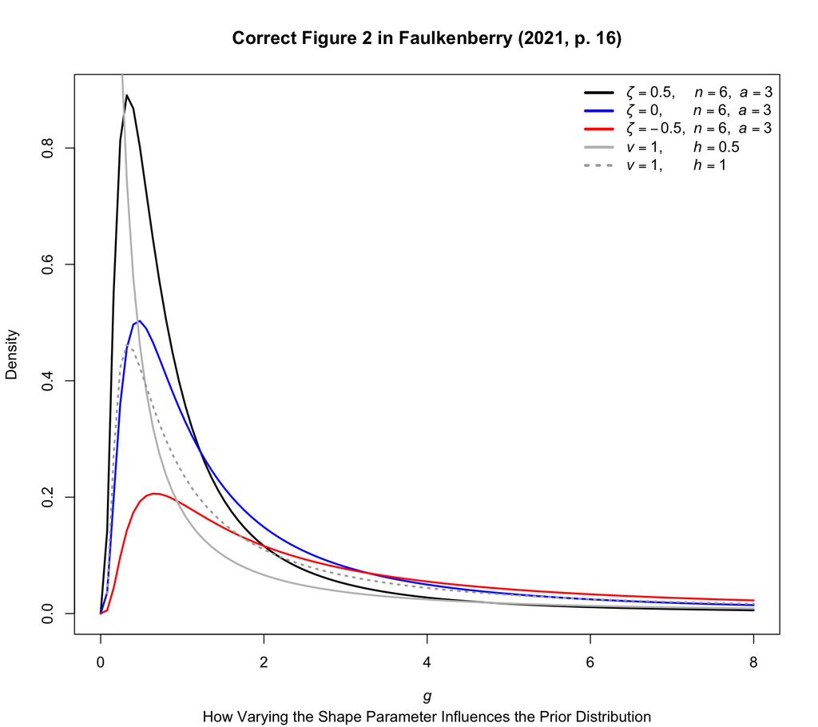

```r
dbetaprime <- function(x, n, a, zeta, beta = a * (n-1) / 2 - zeta - 2) {
  #' density of the Pearson type VI distribution in Eq. 11 with lambda = 1
  #' alternatively, the generalized beta prime distribution
  n * (n*x)^beta * (1+n*x)^(-zeta-beta-2) / beta(zeta+1, beta+1)
}

dinvchisq <- function(x, nu, h) {
  #' density of the scaled inverse chi-squared distribution
  (h^2 * nu / 2)^(nu / 2) * exp(-nu * h^2 / (2 * x)) / (gamma(nu / 2) * x^(nu / 2 + 1))
}

curve(dbetaprime(x, n=6, a=3, zeta=0.5), ylab="Density", xlab=expression(italic(g)), from=0, to=8, lwd=2)
curve(dbetaprime(x, n=6, a=3, zeta=0), add=T, col="blue", lwd=2)
curve(dbetaprime(x, n=6, a=3, zeta=-0.5), add=T, col="red", lwd=2)
curve(dinvchisq(x, nu=1, h=0.5), add=T, col="gray", lwd=2)
curve(dinvchisq(x, nu=1, h=1), add=T, col="darkgray", lty=3, lwd=2)
title(main="Correct Figure 2 in Faulkenberry (2021, p. 16)",
      sub="How Varying the Shape Parameter Influences the Prior Distribution")
legend("topright", c(expression(italic(ζ)==0.5 * "," ~~~~~italic(n)==6 * "," ~~italic(a)==3),
                     expression(italic(ζ)==0 * "," ~~~~~~~~italic(n)==6 * "," ~~italic(a)==3),
                     expression(italic(ζ)==-0.5 * "," ~~italic(n)==6 * "," ~~italic(a)==3),
                     expression(italic(ν)==1 * "," ~~~~~~~~italic(h)==0.5),
                     expression(italic(ν)==1 * "," ~~~~~~~~italic(h)==1)),
       col=c("black","blue","red","gray","darkgray"), lwd=3, lty=c(rep(1,4),3), bty="n")
```

The black, blue, and red curves represent the generalized beta prime probability density functions, which are used in the Pearson Bayes factor.

The gray and dark gray curves represent the scaled inverse chi-squared probability density functions, which are used in the JZS Bayes factor (Rouder et al., [2017](https://psycnet.apa.org/doi/10.1037/met0000057), p. 310).

$g\sim\beta'(\beta+1,\ \zeta+1,\ \color{lightgray}{\lambda=1，}\ n)\quad\implies\quad\mathbb{E}[g]=\frac{\Gamma(\beta+2)\cdot\Gamma(\zeta)}{n\cdot\Gamma(\beta+1)\cdot\Gamma(\zeta+1)}=\frac{\beta+1}{n\zeta}\ \text{ for }\zeta>0$

$g\sim\text{Scale-inv-}\chi^2(\nu,h^2)\quad\implies\quad\mathbb{E}[g]=\frac{\nu h^2}{\nu-2}\ \text{ for }\nu>2$

Caution Large Sample Size

```r
# recall the first gamma term on the denominator in Eq. 12
c(gamma((3 * 114 - 1) / 2),
  gamma((3 * 115 - 1) / 2)) # suppose 342 and 345 total observations
```

```
## [1] 5.562092e+305           Inf
```

By applying Stirling’s formula $\Gamma(y+z)\thicksim y^z\cdot\Gamma(y)$ as $y\to+\infty$, the gamma ratio in Eq. 12 becomes
$$\begin{equation}
\frac{\Gamma\left(\frac{a(n-1)}{2}\right)}{\Gamma\left(\frac{an-1}{2}\right)}\thicksim\left(\frac{an}{2}\right)^{\frac{1-a}{2}},\quad\text{as
}n\to+\infty
\end{equation}$$

scroll to top

### Test-Based Bayes Factor

Bayes Factors Based on the Sampling Distributions of Test Statistics

Johnson ([2005](https://doi.org/10.1111/j.1467-9868.2005.00521.x)) developed an approach to computing Bayes factors based on test statistics. These Bayes factors are derived by modeling the test statistic and considering its distribution under both the null and alternative hypotheses. The resulting Bayes factor is an approximation of a full Bayes factor. Additionally, priors for the parameter under test are chosen to maximize the marginal density of the data (the test statistic in this context) under the alternative hypothesis, thereby making the test statistic Bayes factor (TSBF) an upper bound on the weight of evidence against the null hypothesis.

Unlike JAB/WAB, the proposed TSBFs are also unable to find evidence in favor of the null hypothesis. That is to say, the range of these measures of evidence is $1\leqslant\textit{BF}_{10}<\infty$.

- TSBFs provide the least conservative measure of evidence against the null hypothesis, yielding relatively larger values of $\mathit{TSBF}_{10}$.
- TSBFs may lack the property of **coherence** ($\textit{BF}_{12}=\textit{BF}_{10}\cdot\textit{BF}_{02}$) due to the different transformations applied to the data.

Given the unusual results we have observed for BIC/PBF in ANOVA when the number of groups is large, we use the TSBFs in our cohort and evaluate them in our simulations.

$$\mathit{TSBF}_{01}=
\begin{cases}\ \tag{14} \left(\frac{1+(N-a)\ /\ (a-1)}{F+(N-a)\ /\
(a-1)}\right)^{\frac{N-1}{2}}\!\cdot F^{\frac{a-1}{2}}, & \text{if }
F>1 \\ \\ \ 1, & \text{otherwise}\end{cases}$$

scroll to top

### Savage–Dickey Density Ratio

**The Savage–Dickey density ratio** is a special form of the Bayes factor for **nested** models by dividing the value of  
the posterior density over the parameters for the alternative model evaluated at the hypothesized value by  
the prior for the same model evaluated at the same point.

$$\begin{equation} \tag{15}
\textit{BF}_{01}:=\frac{p(\boldsymbol{y}\mid
\mathcal{M}_0)}{p(\boldsymbol{y}\mid
\mathcal{M}_1)}=\frac{\color{#0055A4}{p(\boldsymbol{\theta}=\boldsymbol{\theta}_0\mid\boldsymbol{y},\mathcal{M}_1)}}{\color{#EF4135}{p(\boldsymbol{\theta}=\boldsymbol{\theta}_0\mid
\mathcal{M}_1)}}
\end{equation}$$

```r
stancode3M1 <- "
data {
  int<lower=1> N;        // total number of subjects
  int<lower=2> C;        // number of conditions
  vector[N] Y;           // responses (ready for the ragged data structure)
  // int s[C];              // condition sizes (i.e., number of subjects in each condition) [removed features]
  array[C] int s;        // condition sizes [Stan 2.26+ syntax for array declarations]
  vector[C] mVec;        // mean vector for the multivariate normal prior on theta
  matrix[C,C] covMat;    // covariance matrix for the multivariate normal prior on theta
}

parameters {
  vector[C] theta;                                  // combined vector for intercept and slopes
  real<lower=0> sigma;                              // error standard deviation
}

model {
  // Priors
  theta ~ multi_normal(mVec, covMat);               // unit information
  target += -log(sigma);                            // Jeffreys prior

  // Likelihood
  int pos = 1;
  for (i in 1:C) {
    segment(Y, pos, s[i]) ~ normal((i == 1) ? theta[1] : (theta[1] + theta[i]), sigma);
    pos = pos + s[i];
  }
}"

stanmodel3M1 <- rstan::stan_model(model_code=stancode3M1)
```

Suppose $a=3$ (three conditions).

A linear regression model without an intercept is $Y_{ij}=\mu_1\cdot D_{1j}+\mu_2\cdot D_{2j}+\mu_3\cdot D_{3j}+\epsilon_{ij}$,  
where $D_{ij}$ are dummy variables indicating the condition for observation $j$. $\quad\mathcal{H}_0:\mu_1=\mu_2=\mu_3$ is not a point-null hypothesis.

A linear regression model with an intercept is $Y_{ij}=\beta_0+\beta_1\cdot x_{1j}+\beta_2\cdot x_{2j}+\epsilon_{ij}$. $\quad\mathcal{H}_0:\beta_1=\beta_2=0$.

- $\mu_1=\beta_0$
- $\mu_2=\beta_0+\beta_1$
- $\mu_3=\beta_0+\beta_2$

Recall the Wald test statistic and Eq. $8^\prime$ where $\boldsymbol{\theta}=(\beta_1,\ \beta_2)^\top$, $\boldsymbol{\theta}_0=(0,\ 0)^\top$, and $q=a-1=2$.

```r
summary(fitA <- lm(weight ~ group, PlantGrowth))
```

```
##
## Call:
## lm(formula = weight ~ group, data = PlantGrowth)
##
## Residuals:
##     Min      1Q  Median      3Q     Max
## -1.0710 -0.4180 -0.0060  0.2627  1.3690
##
## Coefficients:
##             Estimate Std. Error t value Pr(>|t|)
## (Intercept)   5.0320     0.1971  25.527   <2e-16 ***
## grouptrt1    -0.3710     0.2788  -1.331   0.1944
## grouptrt2     0.4940     0.2788   1.772   0.0877 .
## ---
## Signif. codes:  0 '***' 0.001 '**' 0.01 '*' 0.05 '.' 0.1 ' ' 1
##
## Residual standard error: 0.6234 on 27 degrees of freedom
## Multiple R-squared:  0.2641, Adjusted R-squared:  0.2096
## F-statistic: 4.846 on 2 and 27 DF,  p-value: 0.01591
```

```r
summary(fitB <- lm(weight ~ 0 + group, PlantGrowth)) # summary(lm(weight ~ group - 1, PlantGrowth)) # same
```

```
##
## Call:
## lm(formula = weight ~ 0 + group, data = PlantGrowth)
##
## Residuals:
##     Min      1Q  Median      3Q     Max
## -1.0710 -0.4180 -0.0060  0.2627  1.3690
##
## Coefficients:
##           Estimate Std. Error t value Pr(>|t|)
## groupctrl   5.0320     0.1971   25.53   <2e-16 ***
## grouptrt1   4.6610     0.1971   23.64   <2e-16 ***
## grouptrt2   5.5260     0.1971   28.03   <2e-16 ***
## ---
## Signif. codes:  0 '***' 0.001 '**' 0.01 '*' 0.05 '.' 0.1 ' ' 1
##
## Residual standard error: 0.6234 on 27 degrees of freedom
## Multiple R-squared:  0.9867, Adjusted R-squared:  0.9852
## F-statistic: 665.5 on 3 and 27 DF,  p-value: < 2.2e-16
```

```r
vcov(fitA) # vcov(test) # same
```

```
##             (Intercept)   grouptrt1   grouptrt2
## (Intercept)  0.03885959 -0.03885959 -0.03885959
## grouptrt1   -0.03885959  0.07771919  0.03885959
## grouptrt2   -0.03885959  0.03885959  0.07771919
```

```r
vcov(fitB)
```

```
##            groupctrl  grouptrt1  grouptrt2
## groupctrl 0.03885959 0.00000000 0.00000000
## grouptrt1 0.00000000 0.03885959 0.00000000
## grouptrt2 0.00000000 0.00000000 0.03885959
```

When we exclude the intercept (`resp ~ 0 + grp`), each level of `grp` becomes its own independent dummy variable (i.e., exactly one column is “1” for each observation, all others are “0”), which makes the design matrix columns **orthogonal**. That orthogonality leads to zero covariances and hence a diagonal variance-covariance matrix. `model.matrix(fitB)`

scroll to top

## 2. Simulation

Effect Size

The most common measure of effect size for one-way ANOVA is the observed $\eta^2=\frac{\textit{SS}_{\ \text{between}}}{\textit{SS}_{\ \text{total}}}$.

For example, the observed $\eta^2=.9$ indicates that 90% of the total variance is accounted for by the treatment effect.

- Cohen ([1988](https://doi.org/10.4324/9780203771587), p. 285-287) suggests that the effect sizes are small, medium, and large for $\eta^2\in\{0.01,\ 0.06,\ 0.14\}$, respectively.

In practice, we set the standardized range of population means $d$ (Cohen, [1988](https://doi.org/10.4324/9780203771587), p. 275-280).

$$\begin{align}
d&=\frac{\mu_{\text{max}}-\mu_{\text{min}}}{\sigma_\epsilon} \\
\\
f&=\frac{\sigma_m}{\sigma_\epsilon},\quad\text{where}\quad\sigma_m^2=\frac{1}{a}\sum_{i=1}^a
(\mu_i-\mu)^2=\frac{1}{a}\sum_{i=1}^a t_i^2
\qquad{\color{lightgray}{\text{not to be confused with
}\mathbb{E}\left[\textit{MS}_{\
\text{between}}\right]=\sigma_\epsilon^2+\frac{1}{a-1}\sum_{i=1}^a n_i
t_i^2}} \\
\\
f&=\begin{cases}
\text{$\ d\sqrt{\frac{1}{2a}}$,} & \text{Minimum
variability: One mean at each end of $d$, the remaining $a-2$ means all
at the midpoint} \\
\\
\text{$\ \frac{d}{2}\sqrt{\frac{a+1}{3(a-1)}}$,} &
\text{Intermediate variability: The $a$ means equally spaced over $d$}
\\
\\
\text{$\ d\frac{\sqrt{a^2-1}}{2a}$,} & \text{Maximum
variability: The means all at the end points of $d\qquad$ ($a$ is odd)}
\\
\text{$\ \frac{d}{2}$,} & \text{Maximum variability: The
means all at the end points of $d\qquad$ ($a$ is even)}
\end{cases}
\\ \\
\eta^2&=\frac{\sigma_m^2}{\sigma_\epsilon^2+\sigma_m^2}=\frac{f^2}{1+f^2}
\end{align}$$

Data

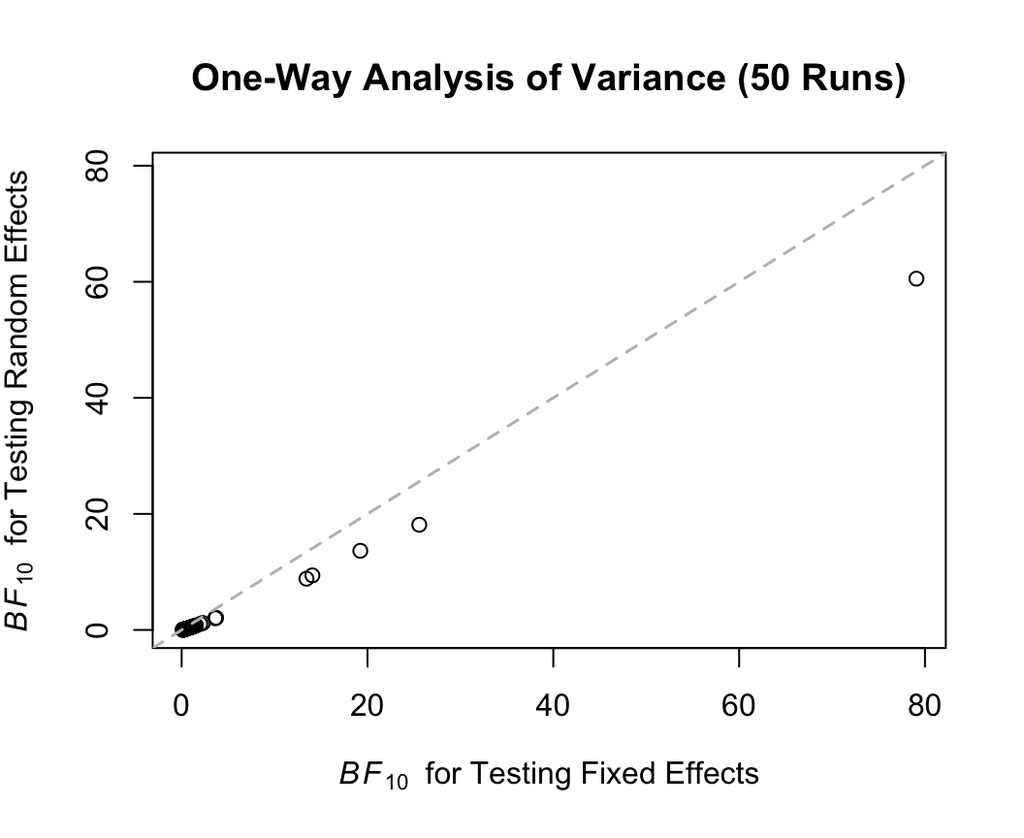

```r
simData4 <- function(n, a=3, m1=0, delta=NULL, sd=1, power=NULL) {
  #' Input -
  #' n:       number of observations per balanced group
  #' a:       number of groups
  #' m1:      population mean of the first group (suppose the lowest)
  #' delta:   population mean difference, m2 - m1 = m3 - m2  = ···
  #'          intermediate variability - the `a` means are equally spaced
  #' sd:      population error standard deviation
  #' power:   statistical power;
  #'          need to input either `delta` or `power`
  #'
  #' Dependency - pwr (v1.3-0)
  #' Output - balanced between-subjects data in the long format

  if (is.null(delta) & !is.null(power)) {
    delta <- sd * 2 * pwr::pwr.anova.test(k=a, n=n, power=power)$f * sqrt(3 / (a^2 - 1))
  } else if (is.null(delta) & is.null(power)) {
    delta <- 0 # simulation under the null
  } else if (!is.null(delta) & !is.null(power)) {stop("Bad input!")}

  # no random seed
  data.frame("resp"=stats::rnorm(n * a, m1 + delta * (1:a - 1), sd),
             "grp"=rep(paste0("grp", 1:a), n),
             stringsAsFactors=T)
}


num <- 50
BF_fix <- BF_rand <- numeric(num)
for (i in 1:num) {
  set.seed(i)
  data <- simData4(n=30, delta=0.25)[sample(1:90,70),] # unbalanced design
  BF_fix[i] <- BayesFactor::extractBF(BayesFactor::anovaBF(resp ~ grp, data, progress=F))$bf
  BF_rand[i] <- BayesFactor::extractBF(BayesFactor::anovaBF(resp ~ grp, whichRandom="grp", data, progress=F))$bf
}
plot(BF_fix, BF_rand, xlim=range(c(BF_fix, BF_rand)), ylim=range(c(BF_fix, BF_rand)),
     xlab=expression(italic(BF)[10]~" for Testing Fixed Effects"),
     ylab=expression(italic(BF)[10]~" for Testing Random Effects"),
     main=paste0("One-Way Analysis of Variance (", num, " Runs)"))
abline(0, 1, col="gray", lty=2, lwd=1.5)
```

The Bayes Factors

**Note**: All the Bayes factors are $\textit{BF}_{01}$.

```r
computeBFs4 <- function(data, zeta=-0.5, ...) {
  #' Input -
  #' data:     between-subjects data in the long format whose columns must be `resp` and `grp`
  #' zeta:     the adjustment of the shape parameters for Output 6
  #' ...       more esoteric options, such as `bgridsize`, in ks::kde
  #'
  #' Global -  stanmodel3M1
  #' Dependency - BayesFactor (v0.9.12-4.7), rstan (v2.32.6), ks (v1.14.3), mvtnorm (v1.3-1)
  #' Output -  a vector of the Bayes factors in favor of the null
  #'           1. Savage–Dickey density ratio using the extended normal unit-information prior
  #'           2. anovaBF function
  #'           3. BIC approximation to the Bayes factor in Eq. 8; BIC(fit) ≡ AIC(fit, k=log(N))
  #'           4. Jeffreys approximate Bayes factor using the normal unit-information prior
  #'           5. Jeffreys approximate Bayes factor using the extended normal unit-information prior
  #'           6. Pearson type VI Bayes factor based on the F-ratio and degrees of freedom in Eq. 12
  #'           7. Test statistic Bayes factor based on the F-ratio and degrees of freedom in Eq. 14

  data <- stats::na.omit(data)
  grp_sizes <- unname(table(data$grp)) # group sizes (can take in imbalance)
  N <- sum(grp_sizes) # total number of observations
  J <- length(grp_sizes) # number of groups

  fit0 <- stats::aov(resp ~ 1, data) # null model fit
  fit1 <- stats::aov(resp ~ grp, data) # full model fit
  pVal <- summary(fit1)[[1]]["grp", "Pr(>F)"] # p-value in one-way ANOVA
  FVal <- stats::qf(1-pVal, J-1, N-J) # F-ratio, ["grp", "F value"]

  datalist <- list(N=N, C=J, Y=data$resp[order(data$grp, data$resp)], s=grp_sizes,
                   mVec=stats::coef(fit1), covMat=stats::vcov(fit1)*(N^(1/(J-1)))) #  <==
  stanfitM1 <- rstan::sampling(stanmodel3M1, data=datalist,
                               iter=15000, warmup=5000, chains=2, seed=277, refresh=0)
  betaS <- rstan::extract(stanfitM1, pars="theta")$theta[,-1]
  dPost <- predict(ks::kde(betaS, ...), x=rep(0, J-1)) # estimated posterior density
  dPrior <- ifelse(J==2,
                   stats::dnorm(0, datalist$mVec[-1], sqrt(datalist$covMat[-1,-1])),
                   mvtnorm::dmvnorm(rep(0, J-1), datalist$mVec[-1], datalist$covMat[-1,-1]))
  SDdr01 <- dPost / dPrior # Savage–Dickey density ratio

  bf <- BayesFactor::anovaBF(resp ~ grp, data, progress=F)
  BF01 <- ifelse(BayesFactor::extractBF(bf)$error < 0.01, # control Monte Carlo errors
                 1 / BayesFactor::extractBF(bf)$bf, NA)

  BICB01 <- exp((stats::BIC(fit1) - stats::BIC(fit0)) / 2) # equiv. AIC(fit, k=log(N)); Eq. 8

  JAB01_UI <- N^((J-1)/2) * exp(-0.5 * FVal * (J-1)) # Eq. 8' & 9, unit-information prior
  JAB01_EXT <- sqrt(N) * exp(-0.5 * FVal * (J-1) * (N^(1/(J-1))-1) / (N^(1/(J-1)))) # extended

  PBF01 <- ifelse(N >= 345, # Eq. 12

                  (N/2)^((J-1)/2) * gamma(1+zeta) *
                    ((N-J) / (N-J+(J-1)*FVal))^((N-J)/2-1-zeta) / gamma((J-1)/2+1+zeta), # in case of Inf/Inf

                  gamma((N-1)/2) * gamma(1+zeta) *
                    ((N-J) / (N-J+(J-1)*FVal))^((N-J)/2-1-zeta) / (gamma((J-1)/2+1+zeta) * gamma((N-J)/2)))

  TSBF01 <- ifelse(FVal == Inf,
                   0, # in case of 0*Inf
                   (((N-J)/(J-1)+1) / ((N-J)/(J-1)+FVal))^((N-1)/2) * (FVal^((J-1)/2))) # Eq. 14

  c("SD"=SDdr01, "anovaBF"=BF01, "BIC_approx"=BICB01,
                 "JAB_OG"=JAB01_UI, "JAB"=JAB01_EXT, "PBF"=PBF01, "TSBF"=ifelse(FVal>1, TSBF01, 1))
}


set.seed(277)
test4 <- simData4(n=30, a=5, delta=0.1)
round(computeBFs4(test4), 2) #  <== HOW COME?
```

```
##         SD    anovaBF BIC_approx     JAB_OG        JAB        PBF       TSBF
##     266.73       9.90    2668.65    2781.71       2.75     917.72       1.00
```

Simulation Study

We aim to conduct several simulation studies to evaluate the accuracy of approximate objective Bayes factors in their ability to convert $p$-values and $n$ reported in scientific articles to Bayesian measures of evidence.

$n_1=n_2=n_3=n$

$\mu_3-\mu_2=\mu_2-\mu_1=\sigma_\epsilon\cdot\delta$

```r
nSim <- 1000 # number of simulation runs for each setting
nSubj <- c(10, 20, 30, 100, 500) # number of observations per balanced group
SMD <- c("Null"=0, "Small"=0.1, "Medium"=0.25, "Large"=0.4) # (standardized) mean differences, m2-m1, given sd=1

reportBF <- reportBF_avg <- reportBF_sd <- reportERR <- reportERR_avg <- reportERR_sd <-
  reportRULE <- reportRULE_H1 <- reportRULE_H0 <- reportRULE_inc <-
  setNames(vector(mode="list", length=length(nSubj) * length(SMD)), # pre-allocation
           apply(expand.grid(names(SMD), nSubj), 1, function(r) paste0("n = ", r[2], ", delta = ", r[1])))

index <- 1 # initial list index

for (n in nSubj) {

  for (delta in SMD) {
    set.seed(n+delta)
    temp <- t(replicate(nSim, computeBFs4(simData4(n, delta=delta)))) # replicate the Bayes factors
    reportBF[[index]] <- temp

    tempRULE_H1 <- temp < 1/3 # support H1
    tempRULE_H0 <- temp > 3 # support H0
    tempRULE_inc <- temp >= 1/3 & temp <= 3 # inconclusive

    # counts of matching decisions for H1
    reportRULE_H1[[index]] <- colSums(tempRULE_H1 * tempRULE_H1[,1], na.rm=T)

    # counts of matching decisions for H0
    reportRULE_H0[[index]] <- colSums(tempRULE_H0 * tempRULE_H0[,1], na.rm=T)

    # counts of matching inconclusiveness
    reportRULE_inc[[index]] <- colSums(tempRULE_inc * tempRULE_inc[,1], na.rm=T)

    tempRULE <- 1*(temp < 1/3) - 1*(temp > 3) # 1: support H1;  0: inconclusive;  -1: support H0
    reportRULE[[index]] <- colSums(tempRULE[,1] == tempRULE, na.rm=T) # counts of matching decisions
    # colMeans(); a value near 1 suggests matching results; the first column should be all 1


    temp[temp[,1]==0,1] <- NA # extremely small SD₀₁ values were rounded down to 0  <==
    reportBF_avg[[index]] <- colMeans(temp, na.rm=T) # mean Bayes factors in favor of the null
    reportBF_sd[[index]] <- apply(na.omit(temp), 2, sd) # sample standard deviations of them

    tempERR <- 100* (temp - temp[,1]) / temp[,1] # percent errors; the first column should be all 0
    reportERR[[index]] <- tempERR # (can take in NA)
    reportERR_avg[[index]] <- colMeans(tempERR, na.rm=T) # mean percent errors
    reportERR_sd[[index]] <- apply(na.omit(tempERR), 2, sd) # sample standard deviations of the percent errors

    index <- index + 1
  }
} # roughly 6.9 hours of run time
```

```r
reshapeW2L3 <- function(list, prob=T, lab=c("SD", "BF", "BIC", "JAB_OG", "JAB", "PBF", "TSBF")) {
  #' Input -
  #' list:    a list of size length(nSubj) * length(SMD);
  #'          reportERR (unaggregated),
  #'          reportRULE, reportRULE_H1, reportRULE_H0, or reportRULE_inc (aggregated)
  #' prob:    logical; if TRUE (default), return the proportions;
  #'                           otherwise, return the original values
  #' lab:     a vector of characters representing the Bayes factor methods
  #'
  #' Global -
  #' nSim:    number of simulation runs for each setting
  #' nSubj:   number of observations per balanced group
  #' SMD:     (standardized) mean differences, m2 - m1, given sd = 1
  #'
  #' Output - unlist the report and reshape the wide into the long

  len <- length(lab) # seven methods
  nRep <- ifelse(!prob, nSim, 1) # nSim if unaggregated; 1 if aggregated
  long <- data.frame("value"=unname(unlist(list)),
                     "method"=factor(rep(rep(1:len, each=nRep), length(list)), labels=lab),
                     "n"=rep(nSubj, each=nRep*len*length(SMD)),
                     "delta"=rep(rep(unname(SMD), each=nRep*len), length(nSubj)))

  if (prob) {
    list2 <- lapply(list, function(vec) {
      if (vec[1] == 0) {
        vec * NA
      } else {
        vec / vec[1] # convert counts to proportions
      }
    })
    list3 <- lapply(list, function(vec) rep(vec[1], length(vec))) # denominator
    long$total <- unname(unlist(list3))
    long$prop <- unname(unlist(list2))
  }
  long
}


formatting2 <- function(val) {
  #' format the value using scientific notation
  if (is.na(val)) {
    "'No entries.'"
  } else if (abs(val) >= 10) {
    paste("~italic(BF)[\"01\"] %~~%",
          gsub("e\\+0*(\\d+)", "%*%10^\\1", sprintf("%.2e", val)))
  } else if (abs(val) < 1) {
    paste("~italic(BF)[\"01\"] %~~%",
          gsub("e-0*(\\d+)", "%*%10^{-\\1}", sprintf("%.2e", val)))
  } else {
    paste("~italic(BF)[\"01\"] %~~%", sprintf("%.2f", val))
  }
}
```

scroll to top

## 3. Graphic Results

Visualization

Note: The gold standard method, `SD`, is the Savage–Dickey density ratio, which assumes the extended normal unit-information prior $\boldsymbol{\theta}\sim\boldsymbol{\mathcal{N}}_{a-1}\!\left(\hat{\boldsymbol{\theta}},\ N^{\frac{1}{a-1}}\cdot I^{-1}(\hat{\boldsymbol{\theta}})\right)$, just as `JAB` does. Meanwhile, `JAB_OG` assumes $\boldsymbol{\theta}\sim\boldsymbol{\mathcal{N}}_{a-1}\!\left(\hat{\boldsymbol{\theta}},\ N\cdot I^{-1}(\hat{\boldsymbol{\theta}})\right)$.

The archived version [0.30.9000](https://osf.io/bkd4p) did not implement the extended JAB, where `SD` and `JAB` used the original normal unit-information prior.

### Boxplot ($\textit{BF}_{01}$)

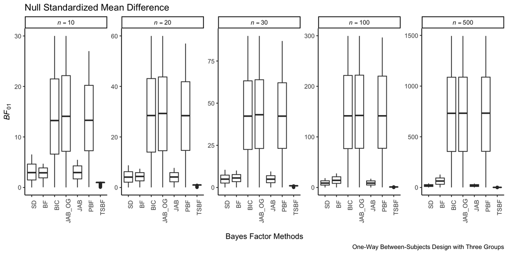

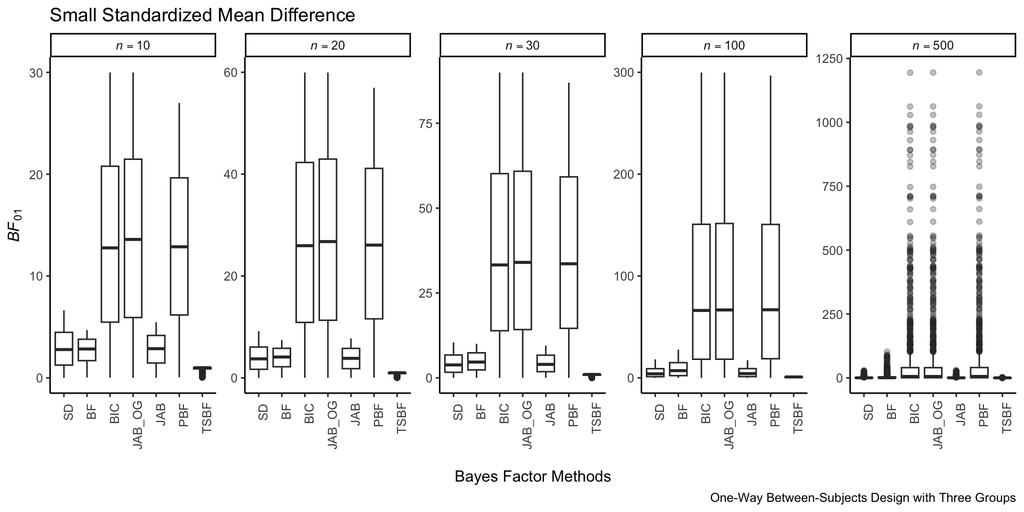

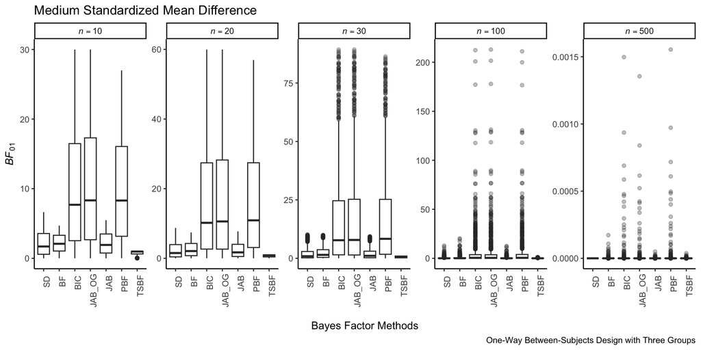

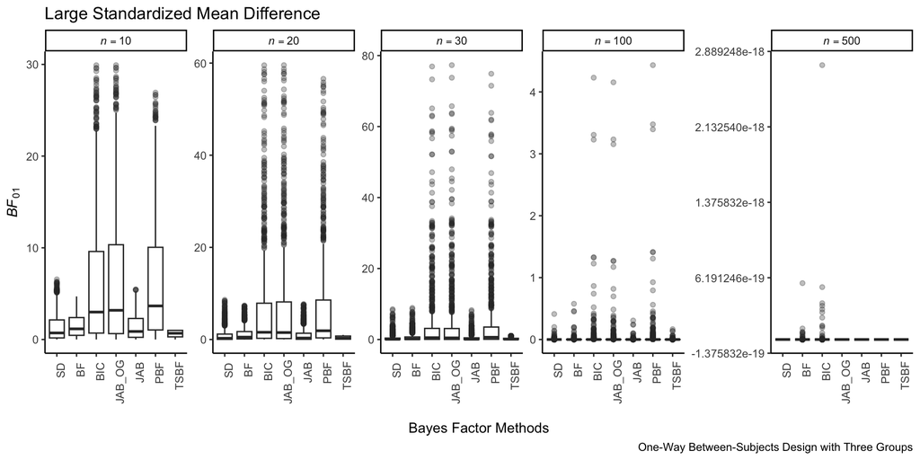

```r
df4_BF <- reshapeW2L3(reportBF, prob=F)

# boxplot of the BF₀₁
for (smd in SMD) {
  sub <- subset(df4_BF, delta == smd) # subset the long
  print(ggplot(sub, aes(x=method, y=value)) +
          geom_boxplot(alpha=0.3, na.rm=T) +
          facet_wrap(.~n, scales="free_y", nrow=1,
                     labeller=label_bquote(cols=italic(n)==.(n))) +
          labs(x="\nBayes Factor Methods", y=expression(italic("BF")["01"]),
               caption="One-Way Between-Subjects Design with Three Groups") +
          ggtitle(paste0(names(SMD[SMD==smd]), " Standardized Mean Difference")) +
          theme_classic() +
          theme(axis.text.x=element_text(angle=90, hjust=0.9)))
  cat("<br><br><br><br><br>")
}
```

scroll to top

### Boxplot (Percent Errors)

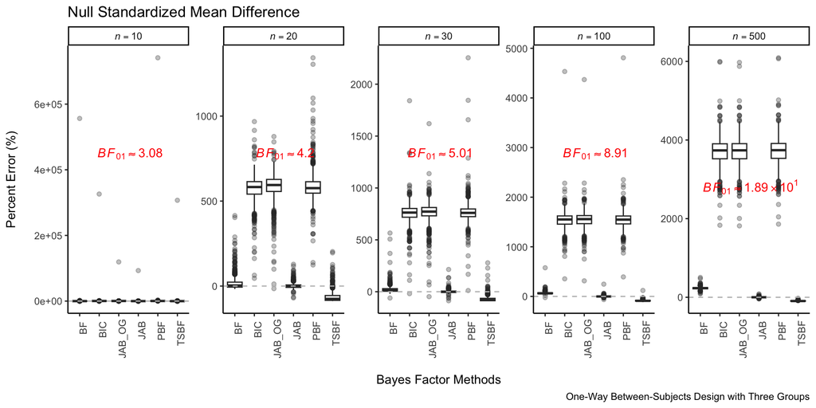

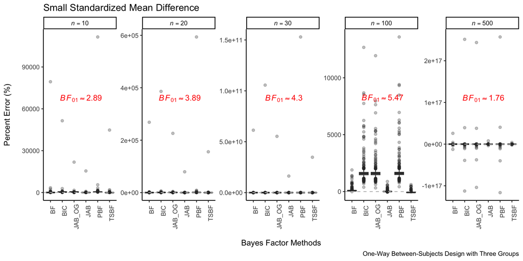

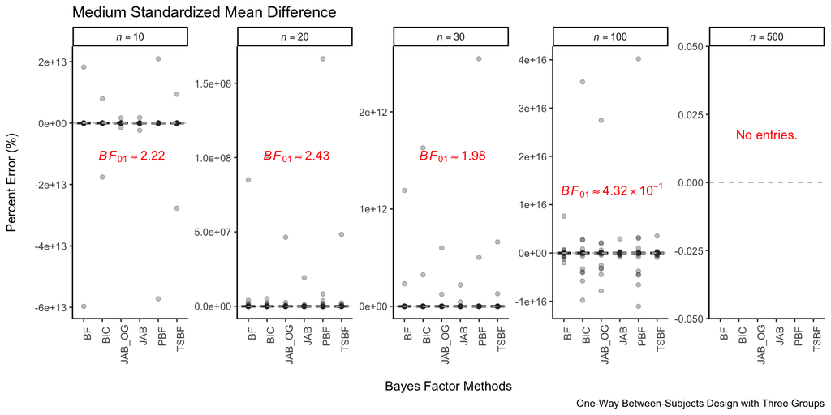

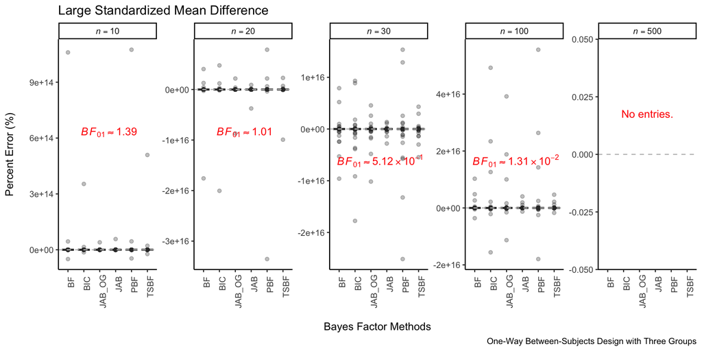

```r
# percent errors
df4 <- reshapeW2L3(reportERR, prob=F)

index <- 0

# boxplot of the percent errors
for (smd in SMD) {
  baseBF01 <- sapply(reportBF_avg[seq(1, by=length(SMD), length.out=length(nSubj)) + index],
                     function(x) x[1]) # baseline is the Savage–Dickey density ratio
  baseBF01_lab <- sapply(baseBF01, formatting2) # scientific notation
  index <- index + 1

  sub <- subset(df4, method != "SD" & delta == smd) # subset the long
  anno <- data.frame("label"=baseBF01_lab, "n"=unique(sub$n),
                     "x"=3.5, "y"=Inf) # for annotation use

  print(ggplot(sub, aes(x=method, y=value)) +
        geom_boxplot(alpha=0.3, na.rm=T) +
        geom_text(data=anno, aes(label=label, x=x, y=y), vjust=10, parse=T, col="red") +
        facet_wrap(.~n, scales="free_y", nrow=1,
           labeller=label_bquote(cols=italic(n)==.(n))) +
        labs(x="\nBayes Factor Methods", y="Percent Error (%)\n",
             caption="One-Way Between-Subjects Design with Three Groups") +
        ggtitle(paste0(names(SMD[SMD==smd]), " Standardized Mean Difference")) +
        geom_hline(yintercept=0, linetype="dashed", color="gray") + # reference line 0%
        theme_classic() +
        theme(axis.text.x=element_text(angle=90, hjust=0.9)))
  cat("<br><br><br><br><br><br><br>")
}
```

Note: For large samples and effect sizes, the evidence against the null hypothesis is substantial. Consequently, R has rounded the negligible Savage–Dickey density ratio $\textit{BF}_{01}$ down to 0, leading to no available entries for calculating the percent error.

scroll to top

### Line Chart (Proportions of Agreement)

[interactive chart not shown]

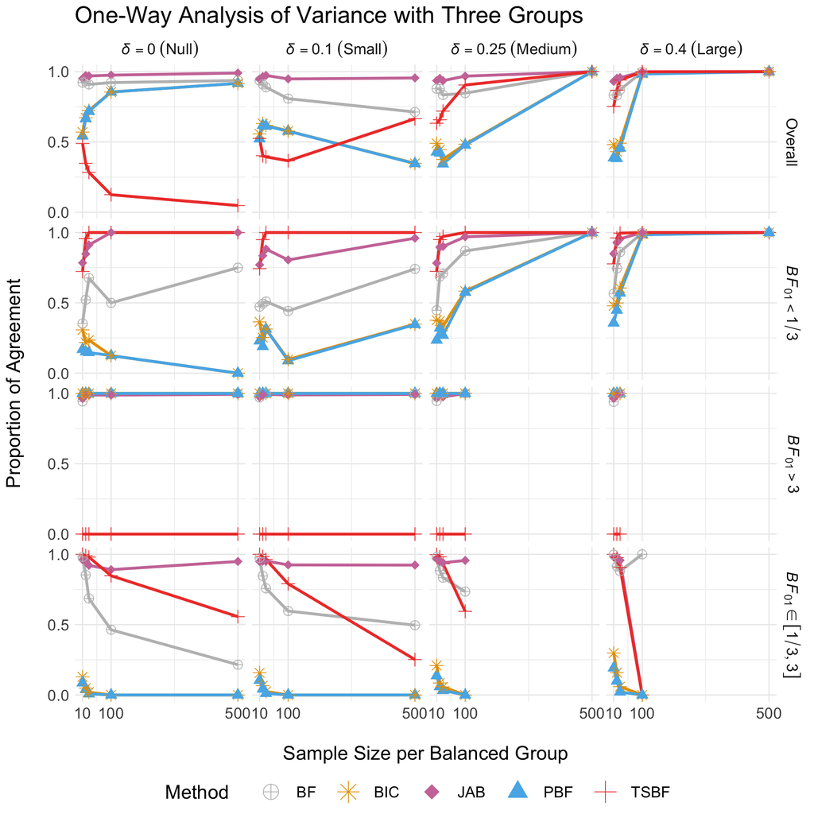

```r
# decisions
decis4 <- rbind(reshapeW2L3(reportRULE),
                reshapeW2L3(reportRULE_H1),
                reshapeW2L3(reportRULE_H0),
                reshapeW2L3(reportRULE_inc))
decis4$result <- factor(rep(c("Overall", "BF01 < 1/3", "BF01 > 3", "[1/3, 3]"),
                            each=length(levels(df4$method)) * length(nSubj) * length(SMD)),
                        levels=c("Overall", "BF01 < 1/3", "BF01 > 3", "[1/3, 3]"))
decis4$delta <- paste0("ES = ", decis4$delta)
decis4 <- decis4[!is.na(decis4[,"prop"]),]
if (F) {
  # compute the pointwise confidence intervals using the normal approximation
  decis4$half.len <- qnorm(1-.05/2) *
    sqrt(decis4$value * (decis4$total - decis4$value) / decis4$total^3) # 95% CI width
  decis4$lwr <- max(0, decis4$value / decis4$total - decis4$half.len) # 95% CI lower bound
  decis4$upr <- min(1, decis4$value / decis4$total + decis4$half.len) # 95% CI upper bound
} else { # Jeffreys intervals
  decis4$lwr <- qbeta(.05/2, decis4$value, decis4$total - decis4$value + 1) # 95% CI lower bound
  decis4$upr <- qbeta(1-.05/2, decis4$value + 1, decis4$total - decis4$value) # 95% CI upper bound
  decis4$half.len <- (decis4$upr - decis4$lwr) / 2 # 95% CI width
}

# line chart of the proportions of agreement
ggplotly(ggplot(decis4, aes(n, prop, color=method, label=value)) +
           geom_line(linewidth=1.2, na.rm=T) + geom_point(size=2, na.rm=T) +
           geom_ribbon(aes(ymin=lwr, ymax=upr), alpha=.2) +
           scale_color_manual(values=c("black", "gray", "#E69F00", "#D55E00", "#CC79A7", "#56B4E9", "#EF4135"),
                              labels=c("SD", "BF", "BIC", "JAB_OG", "JAB", "PBF", "TSBF")) +
           facet_grid(result~delta) +
           labs(x="Sample Size per Balanced Group", y="Proportion of Agreement", color="Method") +
           scale_x_continuous(breaks=c(10, 100, 500)) +
           scale_y_continuous(breaks=c(0, 0.5, 1)) + # min(decis4$prop, na.rm=T)
           theme_minimal()) # interactive plots
```

scroll to top

### **Eureka!**

Since all the methods have solutions in $t$-tests and balanced one-way ANOVA, simulation studies may not be necessary.

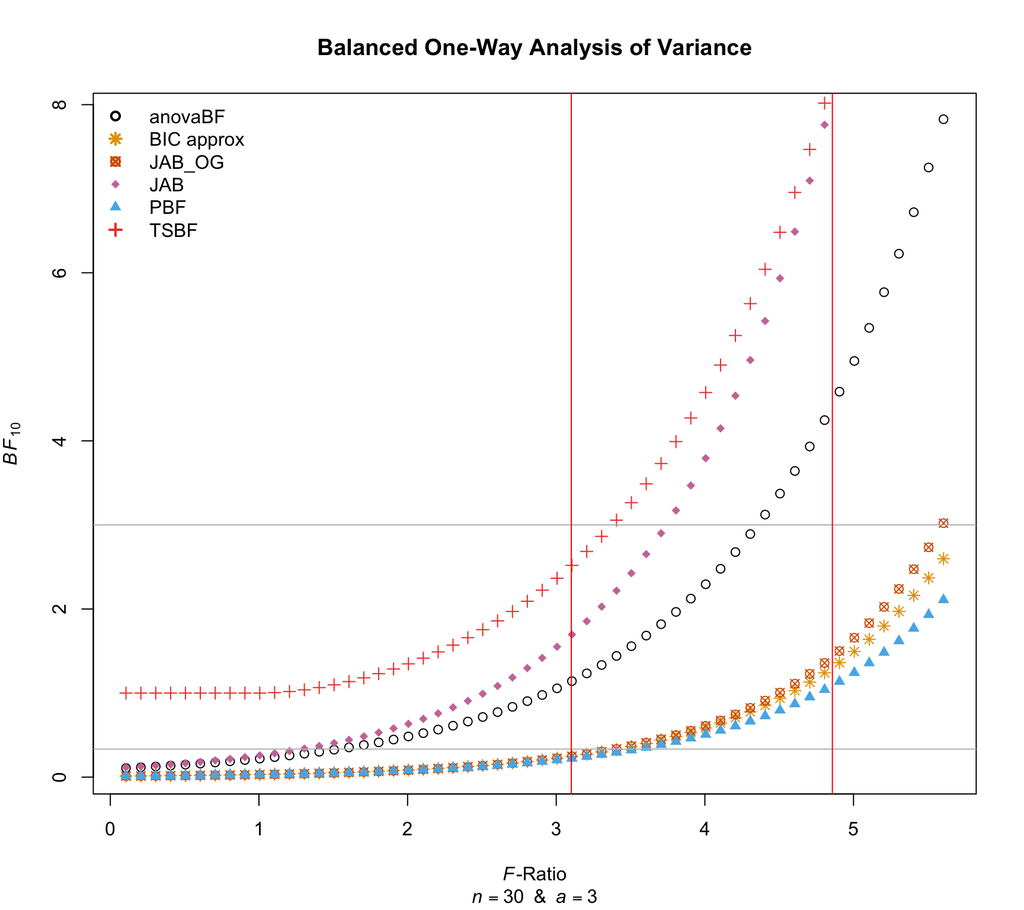

```r
BF10 <- function(F_ratio) {
  h <- 0.5 # prior scale on the variability of fixed effects
  coef <- (2*pi)^(-0.5) * h
  integrand <- function(g) {
    K <- 1 + n*g / (1 + F_ratio * (a-1)/(a*n-a))
    (1+n*g)^((a*n-a)/2) * K^((1-a*n)/2) * g^(-1.5) * exp(-h^2/(2*g))
  }
  unname(coef * integrate(integrand, lower=0, upper=Inf)$value)
}

BIC01 <- function(F_ratio) {
  N <- a * n # total number of observations
  df1 <- a - 1 # condition (between-groups) degrees of freedom
  df2 <- a * (n - 1) # error (within-groups) degrees of freedom
  sqrt(N^df1 * (1 + F_ratio * df1 / df2)^(-N))
}

JAB01_OG <- function(F_ratio) {
  N <- a * n # total number of observations
  N^((a-1)/2) * exp(-0.5 * F_ratio * (a-1))
}

JAB01 <- function(F_ratio) {
  N <- a * n # total number of observations
  sqrt(N) * exp(-0.5 * F_ratio * (a-1) * (N^(1/(a-1))-1) / (N^(1/(a-1)))) # extended JAB
}

PBF01 <- function(F_ratio) {
  N <- a * n # total number of observations
  zeta <- -0.5 # adjustment of the shape parameters
  ifelse(N >= 345,
         (N/2)^((a-1)/2) * gamma(1+zeta) *
           ((N-a) / (N-a+(a-1)*F_ratio))^((N-a)/2-1-zeta) / gamma((a-1)/2+1+zeta), # in case of Inf/Inf
         gamma((N-1)/2) * gamma(1+zeta) *
           ((N-a) / (N-a+(a-1)*F_ratio))^((N-a)/2-1-zeta) / (gamma((a-1)/2+1+zeta) * gamma((N-a)/2)))
}

TSBF01 <- function(F_ratio) {
  # Johnson (2005), https://doi.org/10.1111/j.1467-9868.2005.00521.x
  df1 <- a - 1 # condition (between-groups) degrees of freedom
  df2 <- a * (n - 1) # error (within-groups) degrees of freedom
  ifelse(F_ratio > 1,
         ((df2/df1+1) / (df2/df1+F_ratio))^((df1+df2)/2) * (F_ratio^(df1/2)),
         1)
}


# CAUTION: not all `n` and `a` will cause the integrand to converge
n <- 30 # number of observations per balanced group
a <- 3 # number of groups
Fs <- qf(c(.9, .05, .01, .005), a - 1, a * (n - 1), lower.tail=F) # critical values of F
x <- seq(Fs[1], Fs[4], by=0.1) # input sequence
num <- length(x)
bf <- bic <- jab_og <- jab <- pbf <- tsbf <- numeric(num)
for (i in 1:num) {
  bf[i] <- BF10(x[i])                 # JZS Bayes factor
  bic[i] <- BIC01(x[i])               # BIC approximation
  jab_og[i] <- JAB01_OG(x[i])         # Jeffreys approximate Bayes factor
  jab[i] <- JAB01(x[i])               # Extended Jeffreys approximate Bayes factor
  pbf[i] <- PBF01(x[i])               # Pearson Bayes factor
  tsbf[i] <- TSBF01(x[i])             # Test-based Bayes factor
}

plot(x, bf, ylab=expression(italic(BF)[10]), xlab=expression(italic(F) * "-Ratio"),
     main="Balanced One-Way Analysis of Variance", sub=bquote(italic(n)==.(n)~~"&"~~italic(a)==.(a)))
points(x, 1/bic, col="#E69F00", pch=8)
points(x, 1/jab_og, col="#D55E00", pch=13)
points(x, 1/jab, col="#CC79A7", pch=18)
points(x, 1/pbf, col="#56B4E9", pch=17)
points(x, 1/tsbf, col="#EF4135", pch=3)
abline(h=c(1/3, 3), col="gray")
abline(v=c(Fs[2], Fs[3]), col="red")
legend("topleft", c("anovaBF", "BIC approx", "JAB_OG", "JAB", "PBF", "TSBF"),
       col=c("black", "#E69F00", "#D55E00", "#CC79A7", "#56B4E9", "#EF4135"),
       pch=c(1, 8, 13, 18, 17, 3), lty=0, lwd=2, bty="n")
```

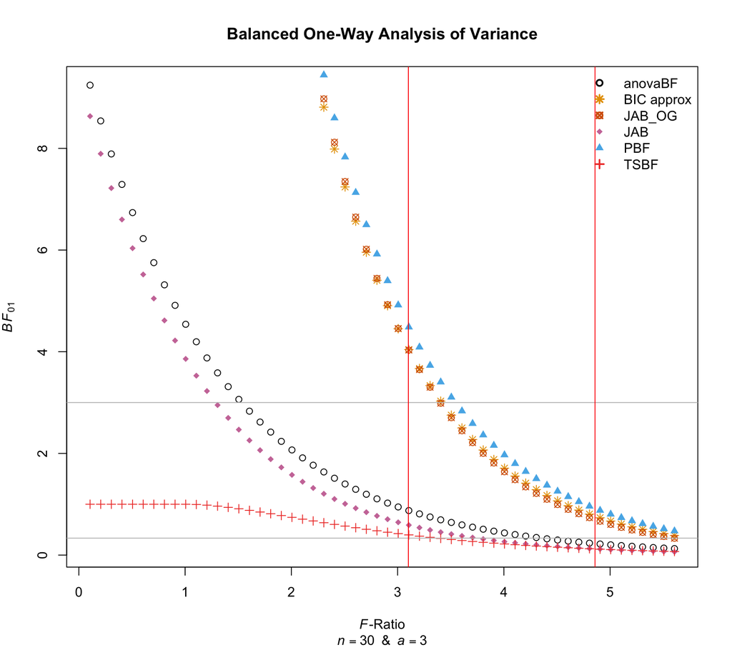

```r
plot(x, 1/bf, ylab=expression(italic(BF)["01"]), xlab=expression(italic(F) * "-Ratio"),
     main="Balanced One-Way Analysis of Variance", sub=bquote(italic(n)==.(n)~~"&"~~italic(a)==.(a)))
points(x, bic, col="#E69F00", pch=8)
points(x, jab_og, col="#D55E00", pch=13)
points(x, jab, col="#CC79A7", pch=18)
points(x, pbf, col="#56B4E9", pch=17)
points(x, tsbf, col="#EF4135", pch=3)
abline(h=c(1/3, 3), col="gray")
abline(v=c(Fs[2], Fs[3]), col="red")
legend("topright", c("anovaBF", "BIC approx", "JAB_OG", "JAB", "PBF", "TSBF"),
       col=c("black", "#E69F00", "#D55E00", "#CC79A7", "#56B4E9", "#EF4135"),
       pch=c(1, 8, 13, 18, 17, 3), lty=0, lwd=2, bty="n")
```

scroll to top

## 4. Decision Rules

Debugging

```r
(mat <- matrix(rep(c(0, -1), 5), nrow=2))
```

```
##      [,1] [,2] [,3] [,4] [,5]
## [1,]    0    0    0    0    0
## [2,]   -1   -1   -1   -1   -1
```

```r
(res <- mat[mat[,1] == -1, 1] == mat[mat[,1] == -1,]) # only one row ==> column vector
```

```
## [1] TRUE TRUE TRUE TRUE TRUE
```

```r
colSums(res) #  ERROR!
```

```
## Error in base::colSums(x, na.rm = na.rm, dims = dims, ...): 'x' must be an array of at least two dimensions
```

```r
colSums(rbind(rep(F, 5), res)) # counts of matching decisions
```

```
## [1] 1 1 1 1 1
```

```r
colSums((mat == -1) * (mat == -1)[,1]) # counts of matching decisions
```

```
## [1] 1 1 1 1 1
```

The counts of matching Bayes factors between the gold standard and approximate methods.

```r
reportRULE
```

```
## $`n =  10, delta = Null`
##         SD    anovaBF BIC_approx     JAB_OG        JAB        PBF       TSBF
##       1000        922        570        568        951        542        489
##
## $`n =  10, delta = Small`
##         SD    anovaBF BIC_approx     JAB_OG        JAB        PBF       TSBF
##       1000        936        557        559        947        522        525
##
## $`n =  10, delta = Medium`
##         SD    anovaBF BIC_approx     JAB_OG        JAB        PBF       TSBF
##       1000        879        490        488        936        429        633
##
## $`n =  10, delta = Large`
##         SD    anovaBF BIC_approx     JAB_OG        JAB        PBF       TSBF
##       1000        833        481        482        931        387        752
##
## $`n =  20, delta = Null`
##         SD    anovaBF BIC_approx     JAB_OG        JAB        PBF       TSBF
##       1000        931        672        672        972        666        348
##
## $`n =  20, delta = Small`
##         SD    anovaBF BIC_approx     JAB_OG        JAB        PBF       TSBF
##       1000        909        631        632        965        618        402
##
## $`n =  20, delta = Medium`
##         SD    anovaBF BIC_approx     JAB_OG        JAB        PBF       TSBF
##       1000        878        444        455        952        421        658
##
## $`n =  20, delta = Large`
##         SD    anovaBF BIC_approx     JAB_OG        JAB        PBF       TSBF
##       1000        831        431        450        953        382        868
##
## $`n =  30, delta = Null`
##         SD    anovaBF BIC_approx     JAB_OG        JAB        PBF       TSBF
##       1000        909        724        725        969        718        284
##
## $`n =  30, delta = Small`
##         SD    anovaBF BIC_approx     JAB_OG        JAB        PBF       TSBF
##       1000        889        618        623        973        613        394
##
```

[output cut: 24 more lines]

```
## $`n = 500, delta = Null`
##         SD    anovaBF BIC_approx     JAB_OG        JAB        PBF       TSBF
##       1000        937        917        917        990        917         48
##
## $`n = 500, delta = Small`
##         SD    anovaBF BIC_approx     JAB_OG        JAB        PBF       TSBF
##       1000        713        348        350        955        346        665
##
## $`n = 500, delta = Medium`
##         SD    anovaBF BIC_approx     JAB_OG        JAB        PBF       TSBF
##       1000       1000       1000       1000       1000       1000       1000
##
## $`n = 500, delta = Large`
##         SD    anovaBF BIC_approx     JAB_OG        JAB        PBF       TSBF
##       1000       1000       1000       1000       1000       1000       1000
```

```r
reportRULE_inc
```

```
## $`n =  10, delta = Null`
##         SD    anovaBF BIC_approx     JAB_OG        JAB        PBF       TSBF
##        442        434         57         52        425         38        442
##
## $`n =  10, delta = Small`
##         SD    anovaBF BIC_approx     JAB_OG        JAB        PBF       TSBF
##        470        458         74         69        446         49        470
##
## $`n =  10, delta = Medium`
##         SD    anovaBF BIC_approx     JAB_OG        JAB        PBF       TSBF
##        511        501        107         98        495         70        510
##
## $`n =  10, delta = Large`
##         SD    anovaBF BIC_approx     JAB_OG        JAB        PBF       TSBF
##        473        472        141        128        464         91        473
##
## $`n =  20, delta = Null`
##         SD    anovaBF BIC_approx     JAB_OG        JAB        PBF       TSBF
##        307        262         15         15        292         12        304
##
## $`n =  20, delta = Small`
##         SD    anovaBF BIC_approx     JAB_OG        JAB        PBF       TSBF
##        332        281         22         22        316         14        327
##
## $`n =  20, delta = Medium`
##         SD    anovaBF BIC_approx     JAB_OG        JAB        PBF       TSBF
##        456        403         39         39        433         27        448
##
## $`n =  20, delta = Large`
##         SD    anovaBF BIC_approx     JAB_OG        JAB        PBF       TSBF
##        352        322         56         55        345         35        344
##
## $`n =  30, delta = Null`
##         SD    anovaBF BIC_approx     JAB_OG        JAB        PBF       TSBF
##        255        175          5          5        235          2        250
##
## $`n =  30, delta = Small`
##         SD    anovaBF BIC_approx     JAB_OG        JAB        PBF       TSBF
##        356        270          9         12        339          4        343
##
```

[output cut: 24 more lines]

```
## $`n = 500, delta = Null`
##         SD    anovaBF BIC_approx     JAB_OG        JAB        PBF       TSBF
##         79         17          0          0         75          0         44
##
## $`n = 500, delta = Small`
##         SD    anovaBF BIC_approx     JAB_OG        JAB        PBF       TSBF
##        262        130          0          0        242          0         66
##
## $`n = 500, delta = Medium`
##         SD    anovaBF BIC_approx     JAB_OG        JAB        PBF       TSBF
##          0          0          0          0          0          0          0
##
## $`n = 500, delta = Large`
##         SD    anovaBF BIC_approx     JAB_OG        JAB        PBF       TSBF
##          0          0          0          0          0          0          0
```

```r
reportRULE_H1
```

```
## $`n =  10, delta = Null`
##         SD    anovaBF BIC_approx     JAB_OG        JAB        PBF       TSBF
##         65         23         20         23         51         11         47
##
## $`n =  10, delta = Small`
##         SD    anovaBF BIC_approx     JAB_OG        JAB        PBF       TSBF
##         74         35         27         34         57         17         55
##
## $`n =  10, delta = Medium`
##         SD    anovaBF BIC_approx     JAB_OG        JAB        PBF       TSBF
##        170         76         64         71        133         40        123
##
## $`n =  10, delta = Large`
##         SD    anovaBF BIC_approx     JAB_OG        JAB        PBF       TSBF
##        359        203        172        186        305        128        279
##
## $`n =  20, delta = Null`
##         SD    anovaBF BIC_approx     JAB_OG        JAB        PBF       TSBF
##         46         24         10         10         39          7         44
##
## $`n =  20, delta = Small`
##         SD    anovaBF BIC_approx     JAB_OG        JAB        PBF       TSBF
##         79         39         20         21         66         15         75
##
## $`n =  20, delta = Medium`
##         SD    anovaBF BIC_approx     JAB_OG        JAB        PBF       TSBF
##        221        152         82         93        198         71        210
##
## $`n =  20, delta = Large`
##         SD    anovaBF BIC_approx     JAB_OG        JAB        PBF       TSBF
##        545        406        272        292        506        244        524
##
## $`n =  30, delta = Null`
##         SD    anovaBF BIC_approx     JAB_OG        JAB        PBF       TSBF
##         34         23          8          9         31          5         34
##
## $`n =  30, delta = Small`
##         SD    anovaBF BIC_approx     JAB_OG        JAB        PBF       TSBF
##         51         26         16         18         45         16         51
##
```

[output cut: 24 more lines]

```
## $`n = 500, delta = Null`
##         SD    anovaBF BIC_approx     JAB_OG        JAB        PBF       TSBF
##          4          3          0          0          4          0          4
##
## $`n = 500, delta = Small`
##         SD    anovaBF BIC_approx     JAB_OG        JAB        PBF       TSBF
##        599        444        209        211        575        207        599
##
## $`n = 500, delta = Medium`
##         SD    anovaBF BIC_approx     JAB_OG        JAB        PBF       TSBF
##       1000       1000       1000       1000       1000       1000       1000
##
## $`n = 500, delta = Large`
##         SD    anovaBF BIC_approx     JAB_OG        JAB        PBF       TSBF
##       1000       1000       1000       1000       1000       1000       1000
```

```r
reportRULE_H0
```

```
## $`n =  10, delta = Null`
##         SD    anovaBF BIC_approx     JAB_OG        JAB        PBF       TSBF
##        493        465        493        493        475        493          0
##
## $`n =  10, delta = Small`
##         SD    anovaBF BIC_approx     JAB_OG        JAB        PBF       TSBF
##        456        443        456        456        444        456          0
##
## $`n =  10, delta = Medium`
##         SD    anovaBF BIC_approx     JAB_OG        JAB        PBF       TSBF
##        319        302        319        319        308        319          0
##
## $`n =  10, delta = Large`
##         SD    anovaBF BIC_approx     JAB_OG        JAB        PBF       TSBF
##        168        158        168        168        162        168          0
##
## $`n =  20, delta = Null`
##         SD    anovaBF BIC_approx     JAB_OG        JAB        PBF       TSBF
##        647        645        647        647        641        647          0
##
## $`n =  20, delta = Small`
##         SD    anovaBF BIC_approx     JAB_OG        JAB        PBF       TSBF
##        589        589        589        589        583        589          0
##
## $`n =  20, delta = Medium`
##         SD    anovaBF BIC_approx     JAB_OG        JAB        PBF       TSBF
##        323        323        323        323        321        323          0
##
## $`n =  20, delta = Large`
##         SD    anovaBF BIC_approx     JAB_OG        JAB        PBF       TSBF
##        103        103        103        103        102        103          0
##
## $`n =  30, delta = Null`
##         SD    anovaBF BIC_approx     JAB_OG        JAB        PBF       TSBF
##        711        711        711        711        703        711          0
##
## $`n =  30, delta = Small`
##         SD    anovaBF BIC_approx     JAB_OG        JAB        PBF       TSBF
##        593        593        593        593        589        593          0
##
```

[output cut: 24 more lines]

```
## $`n = 500, delta = Null`
##         SD    anovaBF BIC_approx     JAB_OG        JAB        PBF       TSBF
##        917        917        917        917        911        917          0
##
## $`n = 500, delta = Small`
##         SD    anovaBF BIC_approx     JAB_OG        JAB        PBF       TSBF
##        139        139        139        139        138        139          0
##
## $`n = 500, delta = Medium`
##         SD    anovaBF BIC_approx     JAB_OG        JAB        PBF       TSBF
##          0          0          0          0          0          0          0
##
## $`n = 500, delta = Large`
##         SD    anovaBF BIC_approx     JAB_OG        JAB        PBF       TSBF
##          0          0          0          0          0          0          0
```

scroll to top

## 5. Finite Sample Correction

Using a power transformation, it can be shown that $\textit{JAB_OG}_{01}^{\ *}=\textit{JAB_OG}_{01}^{\frac{N-1}{N}}\cdot N^{\frac{a-1}{2N}}$.

$n_1=n_2=n_3=10$

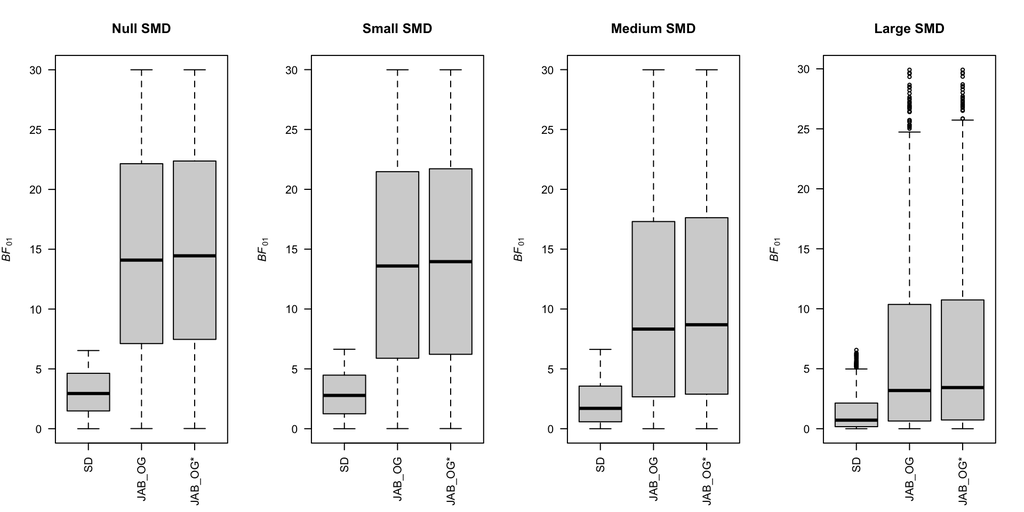

```r
par(mfrow=c(1, length(SMD)))
for (i in 1:length(SMD)) {
  reportBF[[i]][,5] <- reportBF[[i]][,4]^(29/30) * 30^(2/60) # total number of observations is 10 * 3
  boxplot(reportBF[[i]][,c(1,4:5)], names=c("SD", "JAB_OG", "JAB_OG*"),
          xlab="", ylab=expression(italic("BF")["01"]), main=paste0(names(SMD)[i], " SMD"), las=2)
}
```

scroll to top

## 6. Higher Dimensions

### Problem

We are likely to encounter issues with unreliable multivariate density estimation when $a>3$.

A linear regression model without an intercept does not test a point-null hypothesis, but rather $\mathcal{H}_0:\mu_1=\dotsb=\mu_a$.

- The size of the parameters is $a$, not $a-1$. Thus, $\boldsymbol{\mu}\sim\boldsymbol{\mathcal{N}}_a\!\left(\hat{\boldsymbol{\mu}},\ N^{\frac{1}{a}}\cdot I^{-1}(\hat{\boldsymbol{\mu}})\right)$
- In general, we do not know the hypothesized population means $\mu_1=\dotsb=\mu_a=\phi$, unless they are set in simulation studies.
- Based on our data-generating function `simData4`, $\phi$ is the mean of an arithmetic series, i.e., `m1` + `(a-1)` × `delta` / 2.

It is also noted that the inverse of the Fisher information matrix is a diagonal matrix, due to the orthogonality of the design matrix.

- Hence, a multivariate normal distribution becomes the product of several univariate normal distributions.

Danger Zone:

Use MCMC methods (e.g., a Stan No-U-Turn sampler) to estimate parameters that are independent of each other, *a priori*

The joint posterior density, based on posterior samples of the parameters, is **not** a product of independent univariate densities of specific forms, **but** a multivariate density that exhibits dependency.

Now, we consider $a=5$ (five conditions).

```r
stancode3M2 <- "
data {
  int<lower=1> N;        // total number of subjects
  int<lower=2> C;        // number of conditions
  vector[N] Y;           // responses (ready for the ragged data structure)
  // int s[C];              // condition sizes (i.e., number of subjects in each condition) [removed features]
  array[C] int s;        // condition sizes [Stan 2.26+ syntax for array declarations]
  vector[C] mVec;        // mean vector for the multivariate normal prior on theta
  matrix[C,C] covMat;    // covariance matrix for the multivariate normal prior on theta
}

parameters {
  vector[C] theta;                                  // condition means
  real<lower=0> sigma;                              // error standard deviation
}

model {
  // Priors
  theta ~ multi_normal(mVec, covMat);               // unit information
  target += -log(sigma);                            // Jeffreys prior

  // Likelihood
  int pos = 1;
  for (i in 1:C) {
    segment(Y, pos, s[i]) ~ normal(theta[i], sigma);
    pos = pos + s[i];
  }
}"

stanmodel3M2 <- rstan::stan_model(model_code=stancode3M2)


n <- 30; a <- 5; m1 <- 0; delta <- 0.1; phi <- m1 + (a-1) * delta / 2
# set.seed(277); test4 <- simData4(n, a, m1, delta) # cf. the "2. Simulation" section
fit_a5 <- lm(resp ~ 0 + grp, test4)

datalist2 <- list(N=n*a, C=a, Y=test4$resp[order(test4$grp, test4$resp)], s=rep(n, a),
                  mVec=coef(fit_a5), covMat=vcov(fit_a5)*((n*a)^(1/a)))
stanfitM2 <- rstan::sampling(stanmodel3M2, data=datalist2,
                             iter=15000, warmup=5000, chains=2, seed=277, refresh=0)
muS <- rstan::extract(stanfitM2, pars="theta")$theta
dPost <- prod(apply(muS, 2, function(col) polspline::dlogspline(phi, polspline::logspline(col))))
dPrior <- mvtnorm::dmvnorm(rep(phi, a), datalist2$mVec, datalist2$covMat)
c("Numerator"=dPost, "Denominator"=dPrior, "BF₀₁"=dPost / dPrior) # Savage–Dickey density ratio
```

```
##   Numerator Denominator        BF₀₁
##    6.285143    1.899381    3.309048
```

scroll to top

### Code

```r
alterBFs4 <- function(data, phi, zeta=-0.5) {
  #' Input -
  #' data:     between-subjects data in the long format whose columns must be `resp` and `grp`
  #' phi:      true value of the mean
  #' zeta:     the adjustment of the shape parameters for Output 6
  #'
  #' Global -  stanmodel3M2
  #' Dependency - BayesFactor (v0.9.12-4.7), rstan (v2.32.6), polspline (v1.1.25), mvtnorm (v1.3-1)
  #' Output -  a vector of the Bayes factors in favor of the null
  #'           1. Savage–Dickey density ratio using the normal unit-information prior
  #'           2. anovaBF function
  #'           3. BIC approximation to the Bayes factor in Eq. 8; BIC(fit) ≡ AIC(fit, k=log(N))
  #'           4. Jeffreys approximate Bayes factor using the normal unit-information prior
  #'           5. Jeffreys approximate Bayes factor using the extended normal unit-information prior
  #'           6. Pearson type VI Bayes factor based on the F-ratio and degrees of freedom in Eq. 12
  #'           7. Test statistic Bayes factor based on the F-ratio and degrees of freedom in Eq. 14

  data <- stats::na.omit(data)
  grp_sizes <- unname(table(data$grp)) # group sizes (can take in imbalance)
  N <- sum(grp_sizes) # total number of observations
  J <- length(grp_sizes) # number of groups

  fit0 <- stats::aov(resp ~ 1, data) # null model fit
  fit1 <- stats::aov(resp ~ grp, data) # full model fit
  pVal <- summary(fit1)[[1]]["grp", "Pr(>F)"] # p-value in one-way ANOVA
  FVal <- stats::qf(1-pVal, J-1, N-J) # F-ratio, ["grp", "F value"]

  fitM <- stats::lm(resp ~ 0 + grp, data) # without an intercept

  datalist2 <- list(N=N, C=J, Y=data$resp[order(data$grp, data$resp)], s=grp_sizes,
                    mVec=stats::coef(fitM), covMat=stats::vcov(fitM)*(N^(1/J))) #  <==
  stanfitM2 <- rstan::sampling(stanmodel3M2, data=datalist2,
                               iter=15000, warmup=5000, chains=2, seed=277, refresh=0)
  muS <- rstan::extract(stanfitM2, pars="theta")$theta
  dPost <- prod(apply(muS, 2, function(col) polspline::dlogspline(phi, polspline::logspline(col))))
  dPrior <- mvtnorm::dmvnorm(rep(phi, J), datalist2$mVec, datalist2$covMat)
  SDdr01 <- dPost / dPrior # Savage–Dickey density ratio

  bf <- BayesFactor::anovaBF(resp ~ grp, data, progress=F)
  BF01 <- ifelse(BayesFactor::extractBF(bf)$error < 0.01, # control Monte Carlo errors
                 1 / BayesFactor::extractBF(bf)$bf, NA)

  BICB01 <- exp((stats::BIC(fit1) - stats::BIC(fit0)) / 2) # equiv. AIC(fit, k=log(N)); Eq. 8

  JAB01_UI <- N^((J-1)/2) * exp(-0.5 * FVal * (J-1)) # Eq. 8' & 9, unit-information prior
  JAB01_EXT <- sqrt(N) * exp(-0.5 * FVal * (J-1) * (N^(1/(J-1))-1) / (N^(1/(J-1)))) # extended

  PBF01 <- ifelse(N >= 345, # Eq. 12

                  (N/2)^((J-1)/2) * gamma(1+zeta) *
                    ((N-J) / (N-J+(J-1)*FVal))^((N-J)/2-1-zeta) / gamma((J-1)/2+1+zeta), # in case of Inf/Inf

                  gamma((N-1)/2) * gamma(1+zeta) *
                    ((N-J) / (N-J+(J-1)*FVal))^((N-J)/2-1-zeta) / (gamma((J-1)/2+1+zeta) * gamma((N-J)/2)))

  TSBF01 <- ifelse(FVal == Inf,
                   0, # in case of 0*Inf
                   (((N-J)/(J-1)+1) / ((N-J)/(J-1)+FVal))^((N-1)/2) * (FVal^((J-1)/2))) # Eq. 14

  c("SD"=SDdr01, "anovaBF"=BF01, "BIC_approx"=BICB01,
                 "JAB_OG"=JAB01_UI, "JAB"=JAB01_EXT, "PBF"=PBF01, "TSBF"=ifelse(FVal>1, TSBF01, 1))
}
```

$n_1=n_2=n_3=n_4=n_5=n$

$\mu_5-\mu_4=\mu_4-\mu_3=\mu_3-\mu_2=\mu_2-\mu_1=\sigma_\epsilon\cdot\delta$

```r
SMD <- c("Null"=0, "Small"=0.2, "Medium"=0.5, "Large"=0.8) / (a-1)
mu_H0 <- 0 + (a-1) * SMD / 2 # hypothesized population mean

reportBF <- reportBF_avg <- reportBF_sd <- reportERR <- reportERR_avg <- reportERR_sd <-
  reportRULE <- reportRULE_H1 <- reportRULE_H0 <- reportRULE_inc <-
  setNames(vector(mode="list", length=length(nSubj) * length(SMD)), # pre-allocation
           apply(expand.grid(names(SMD), nSubj), 1, function(r) paste0("n = ", r[2], ", delta = ", r[1])))

index <- 1 # initial list index

for (n in nSubj) {
  index2 <- 1 # index of `delta` in `SMD`

  for (delta in SMD) {
    set.seed(n+delta)
    temp <- t(replicate(nSim, alterBFs4(simData4(n, a, delta=delta), mu_H0[index2])))
    reportBF[[index]] <- temp

    tempRULE_H1 <- temp < 1/3 # support H1
    tempRULE_H0 <- temp > 3 # support H0
    tempRULE_inc <- temp >= 1/3 & temp <= 3 # inconclusive

    # counts of matching decisions for H1
    reportRULE_H1[[index]] <- colSums(tempRULE_H1 * tempRULE_H1[,1], na.rm=T)

    # counts of matching decisions for H0
    reportRULE_H0[[index]] <- colSums(tempRULE_H0 * tempRULE_H0[,1], na.rm=T)

    # counts of matching inconclusiveness
    reportRULE_inc[[index]] <- colSums(tempRULE_inc * tempRULE_inc[,1], na.rm=T)

    tempRULE <- 1*(temp < 1/3) - 1*(temp > 3) # 1: support H1;  0: inconclusive;  -1: support H0
    reportRULE[[index]] <- colSums(tempRULE[,1] == tempRULE, na.rm=T) # counts of matching decisions
    # colMeans(); a value near 1 suggests matching results; the first column should be all 1


    temp[temp[,1]==0,1] <- NA # extremely small SD₀₁ values were rounded down to 0  <==
    reportBF_avg[[index]] <- colMeans(temp, na.rm=T) # mean Bayes factors in favor of the null
    reportBF_sd[[index]] <- apply(na.omit(temp), 2, sd) # sample standard deviations of them

    tempERR <- 100* (temp - temp[,1]) / temp[,1] # percent errors; the first column should be all 0
    reportERR[[index]] <- tempERR # (can take in NA)
    reportERR_avg[[index]] <- colMeans(tempERR, na.rm=T) # mean percent errors
    reportERR_sd[[index]] <- apply(na.omit(tempERR), 2, sd) # sample standard deviations of the percent errors

    index <- index + 1
    index2 <- index2 + 1
  }
} # roughly 6.3 hours of run time

# There were 50 or more warnings:
# 1: In polspline::logspline(col) :  Not all models could be fitted
# 2: In polspline::logspline(col) : too much data close together
# 3: In polspline::logspline(col) : re-ran with oldlogspline
# ...
```

scroll to top

### Boxplot ($\textit{BF}_{01}$)

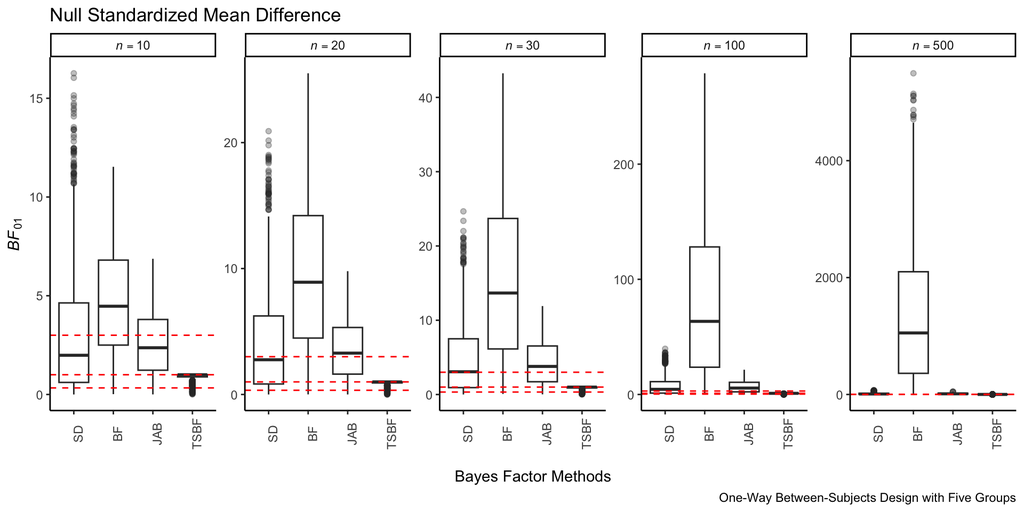

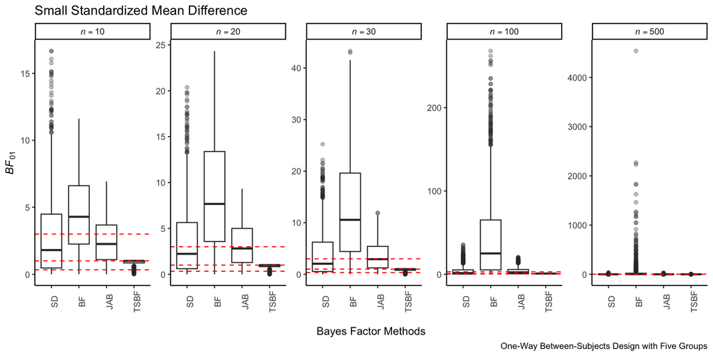

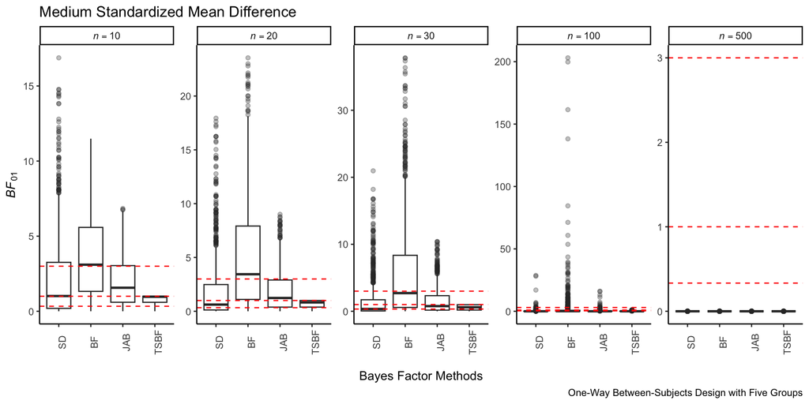

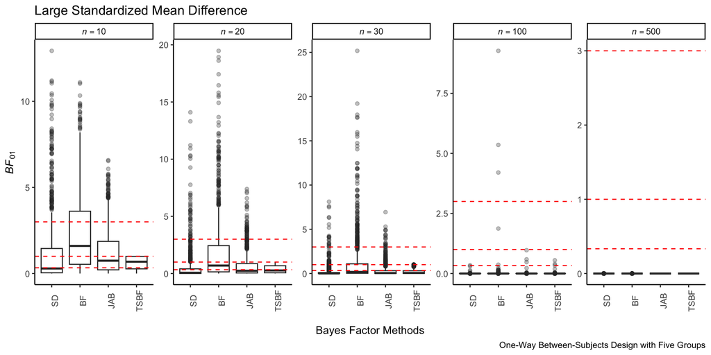

scroll to top

## 7. Two-Way ANOVA

### Models

In a two-way ANOVA, we compare an additive model, $\mathcal{M}_{\text{add}}$, to a model, $\mathcal{M}_{\text{omitA}}$, which omits the factor being tested, suppose factor $A$, in testing $\mathcal{H}_0:\alpha_i=0$ versus $\mathcal{H}_1:$ at least one $\alpha_i\neq0$.

$$\begin{align}
\mathcal{M}_{\text{full}}:\
Y_{ijk}&=\mu+\alpha_i+\beta_j+(\alpha\beta)_{ij}+\epsilon_{ijk} \\
\mathcal{M}_{\text{add}}:\
Y_{ijk}&=\mu+\alpha_i+\beta_j+\epsilon_{ijk} \\
\mathcal{M}_{\text{omitA}}:\ Y_{ijk}&=\mu+\beta_j+\epsilon_{ijk}
\\
\mathcal{M}_{\text{omitB}}:\
Y_{ijk}&=\mu+\alpha_i+\epsilon_{ijk},\qquad\epsilon_{ijk}\overset{\text{i.i.d.}}{\sim}\mathcal{N}(0,\
\sigma_\epsilon^2) \\
&\qquad\text{for}\ i=1,\dotsb,I;\ j=1,\dotsb,J;\ \text{and
(unbalanced)}\ k=1,\dotsb,n_{ij}\neq1
\end{align}$$

The sum-to-zero constraints impose that $\sum_{i=1}^I\alpha_i=0$, $\sum_{j=1}^J\beta_j=0$, and $\sum_{i=1}^I(\alpha\beta)_{ij}=\sum_{j=1}^J(\alpha\beta)_{ij}=0$.

The number of free parameters in $\mathcal{M}_{\text{add}}$ is given by $1+(I-1)+(J-1)+1=I+J$.

The number of free parameters in $\mathcal{M}_{\text{omitA}}$ is given by $1+(J-1)+1=J+1$.

Thus, the difference in free parameters is $I-1$, which is equivalent to the number of free parameters in a one-way ANOVA.

The sample size in this case is $N=\sum_{i=1}^I\sum_{j=1}^J n_{ij}$. If the design is balanced, then $N=IJn$.

Fractional factorial designs are a subset of factorial designs where only a fraction of all possible treatment combinations is executed. $n_{ij}=0$ for some $i$ and $j$.

scroll to top

### Code

```r
simData2way <- function(n, A=NULL, B=0.5, nA=2, nB=2, sd=1) {
  #' Input -
  #' n:       number of observations per balanced condition
  #' A:       effect size of the first factor (of interest)
  #' B:       effect size of the second factor
  #' nA:      number of levels in the first factor
  #' nB:      number of levels in the second factor
  #' sd:      error standard deviation
  #'
  #' Output - two-way between-subjects data in the long format

  if (nA + nB <= 2) stop("Bad input!") # one-way design: nA > 1 & nB = 1

  C1 <- seq(-.5, .5, length.out=nA) # contrast coded
  C2 <- seq(-.5, .5, length.out=nB)
  M <- cbind(A, B) %*% t(expand.grid(C1, C2)) # cell means: a1b1, a2b1, ..., a1b2, a2b2, ...
                                              # no interaction effect

  # no random seed
  data.frame("resp"=stats::rnorm(n * nA * nB, M, sd),
             "A"=paste0("a", 1:nA),
             "B"=rep(paste0("b", 1:nB), each=nA),
             stringsAsFactors=T)
}

stancodelm <- "
data {
  int<lower=1> N;           // total number of subjects
  int<lower=2> C;           // number of conditions
  vector[N] Y;              // responses (ready for the ragged data structure)
  // int s[C];                 // condition sizes (i.e., number of subjects in each condition) [removed features]
  array[C] int s;           // condition sizes [Stan 2.26+ syntax for array declarations]
  int<lower=1> K;           // number of parameters (including an intercept)
  matrix[C,K] X;            // design matrix
  vector[K] mVec;           // mean vector for the multivariate normal prior
  matrix[K,K] covMat;       // covariance matrix for the multivariate normal prior
}

parameters {
  vector[K] beta;                                   // parameter vector
  real<lower=0> sigma;                              // error standard deviation
}

model {
  // Priors
  beta ~ multi_normal(mVec, covMat);
  target += -log(sigma);                            // Jeffreys prior

  // Likelihood
  int pos = 1;
  for (i in 1:C) {
    segment(Y, pos, s[i]) ~ normal(X[i,] * beta, sigma);
    pos = pos + s[i];
  }
}"

stanlm <- rstan::stan_model(model_code=stancodelm)


computeBFs2way <- function(data, ...) {
  #' Input -
  #' data:     two-way between-subjects data in the long format whose columns must be `resp`, `A`, and `B`
  #' ...       more esoteric options, such as `bgridsize`, in ks::kde
  #'
  #' Global -  stanlm
  #' Dependency - BayesFactor (v0.9.12-4.7), rstan (v2.32.6), ks (v1.14.3), mvtnorm (v1.3-1)
  #' Output -  a vector of the Bayes factors in favor of the null for testing `A`
  #'           1. Savage–Dickey density ratio using the extended normal unit-information prior
  #'           2. lmBF function
  #'           3. BIC approximation to the Bayes factor
  #'           4. Jeffreys approximate Bayes factor using the normal unit-information prior
  #'           5. Jeffreys approximate Bayes factor using the extended normal unit-information prior

  data <- stats::na.omit(data)
  grp_sizes <- unname(c(table(data$A, data$B))) # condition sizes (can take in imbalance)
  grp_sizes <- grp_sizes[grp_sizes != 0] # (take in fractionality)
  N <- sum(grp_sizes) # total number of observations
  C <- length(grp_sizes) # number of conditions
  J <- length(unique(data$A)) # number of levels in `A`

  fit0 <- stats::aov(resp ~ B, data) # omitted model fit
  fit1 <- stats::aov(resp ~ A + B, data) # additive model fit
  pVal <- summary(fit1)[[1]]["A", "Pr(>F)"] # p-value in two-way ANOVA
  FVal <- summary(fit1)[[1]]["A", "F value"] # F-ratio

  fitM <- stats::lm(resp ~ A + B, data)
  designMat <- stats::model.matrix(fitM) # design matrix of all replicates
  datalist3 <- list(N=N, C=C, Y=data$resp[order(data$B, data$A, data$resp)], s=grp_sizes,
                    K=ncol(designMat), X=designMat[1:C,],
                    mVec=stats::coef(fitM), covMat=stats::vcov(fitM)*(N^(1/(J-1)))) #  <==
  stanfitM3 <- rstan::sampling(stanlm, data=datalist3,
                               iter=15000, warmup=5000, chains=2, seed=277, refresh=0)
  betaS <- rstan::extract(stanfitM3, pars="beta")$beta[,2:J]
  dPost <- predict(ks::kde(betaS, ...), x=rep(0, J-1)) # estimated posterior density
  dPrior <- ifelse(J==2,
                   stats::dnorm(0, datalist3$mVec[2], sqrt(datalist3$covMat[2,2])),
                   mvtnorm::dmvnorm(rep(0, J-1), datalist3$mVec[2:J], datalist3$covMat[2:J,2:J]))
  SDdr01 <- dPost / dPrior # Savage–Dickey density ratio

  model_add <- BayesFactor::lmBF(resp ~ A + B, data, progress=F)
  model_omit <- BayesFactor::lmBF(resp ~ B, data, progress=F)
  bf <- model_omit / model_add
  BF01 <- ifelse(BayesFactor::extractBF(bf)$error < 0.05, # control Monte Carlo errors
                 BayesFactor::extractBF(bf)$bf, NA)

  BICB01 <- exp((stats::BIC(fit1) - stats::BIC(fit0)) / 2)

  JAB01_UI <- N^((J-1)/2) * exp(-0.5 * FVal * (J-1)) # unit-information prior
  JAB01_EXT <- sqrt(N) * exp(-0.5 * FVal * (J-1) * (N^(1/(J-1))-1) / (N^(1/(J-1)))) # extended

  c("SD"=SDdr01, "lmBF"=BF01, "BIC_approx"=BICB01, "JAB_OG"=JAB01_UI, "JAB"=JAB01_EXT)
}

# set.seed(277)
# test3x2 <- simData2way(n=30, A=0.3, nA=3)
# computeBFs2way(test3x2)


SMD <- c("Null"=0, "Small"=0.2, "Medium"=0.5, "Large"=0.8)

reportBF <- reportBF_avg <- reportBF_sd <- reportERR <- reportERR_avg <- reportERR_sd <-
  reportRULE <- reportRULE_H1 <- reportRULE_H0 <- reportRULE_inc <-
  setNames(vector(mode="list", length=length(nSubj) * length(SMD)), # pre-allocation
           apply(expand.grid(names(SMD), nSubj), 1, function(r) paste0("n = ", r[2], ", delta = ", r[1])))

index <- 1 # initial list index

for (n in nSubj) {

  for (delta in SMD) {
    set.seed(n+delta)
    temp <- t(replicate(nSim, computeBFs2way(simData2way(n, delta)))) # replicate the Bayes factors
    reportBF[[index]] <- temp

    tempRULE_H1 <- temp < 1/3 # support H1
    tempRULE_H0 <- temp > 3 # support H0
    tempRULE_inc <- temp >= 1/3 & temp <= 3 # inconclusive

    # counts of matching decisions for H1
    reportRULE_H1[[index]] <- colSums(tempRULE_H1 * tempRULE_H1[,1], na.rm=T)

    # counts of matching decisions for H0
    reportRULE_H0[[index]] <- colSums(tempRULE_H0 * tempRULE_H0[,1], na.rm=T)

    # counts of matching inconclusiveness
    reportRULE_inc[[index]] <- colSums(tempRULE_inc * tempRULE_inc[,1], na.rm=T)

    tempRULE <- 1*(temp < 1/3) - 1*(temp > 3) # 1: support H1;  0: inconclusive;  -1: support H0
    reportRULE[[index]] <- colSums(tempRULE[,1] == tempRULE, na.rm=T) # counts of matching decisions
    # colMeans(); a value near 1 suggests matching results; the first column should be all 1


    temp[temp[,1]==0,1] <- NA # extremely small SD₀₁ values were rounded down to 0  <==
    reportBF_avg[[index]] <- colMeans(temp, na.rm=T) # mean Bayes factors in favor of the null
    reportBF_sd[[index]] <- apply(na.omit(temp), 2, sd) # sample standard deviations of them

    tempERR <- 100* (temp - temp[,1]) / temp[,1] # percent errors; the first column should be all 0
    reportERR[[index]] <- tempERR # (can take in NA)
    reportERR_avg[[index]] <- colMeans(tempERR, na.rm=T) # mean percent errors
    reportERR_sd[[index]] <- apply(na.omit(tempERR), 2, sd) # sample standard deviations of the percent errors

    index <- index + 1
  }
} # roughly 4.9 hours of run time
```

scroll to top

### Boxplot ($\textit{BF}_{01}$)

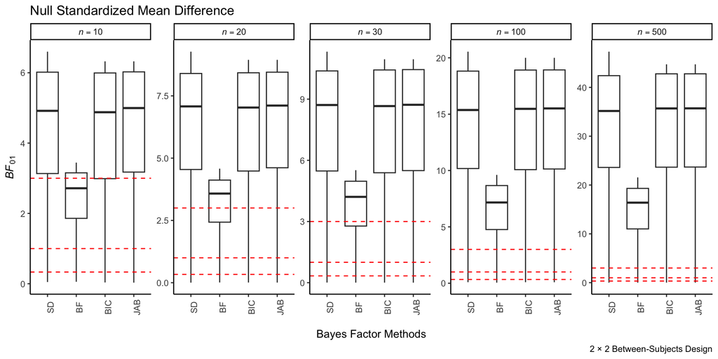

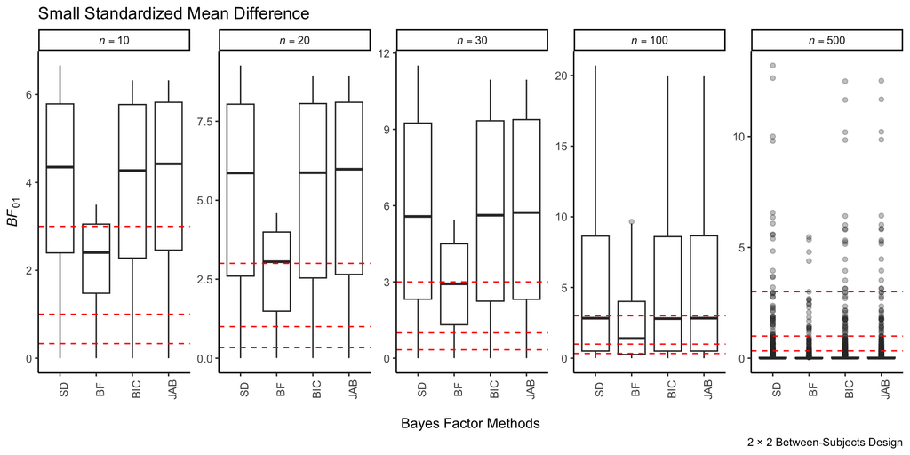

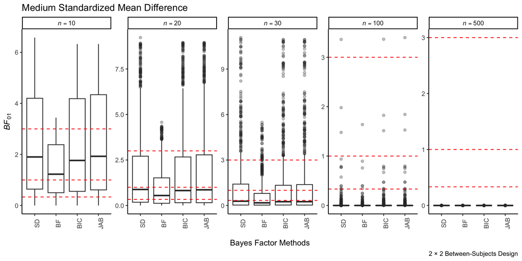

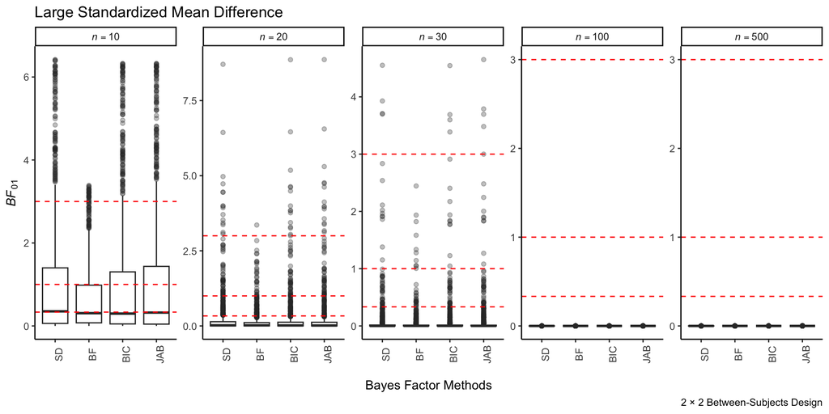

scroll to top

## 8. eJAB

To test the hypotheses $\mathcal{H}_0:\boldsymbol{\theta}=\boldsymbol{\theta}_0$ versus $\mathcal{H}_1:\boldsymbol{\theta}\neq\boldsymbol{\theta}_0$, we define the extended Jeffreys approximate objective Bayes factor (eJAB) as
$$\begin{equation}
\mathit{eJAB}_{01}=\sqrt{N}\exp\left\{-\frac{1}{2}\frac{N^{1/q}-1}{N^{1/q}}\cdot
Q_{\chi^{2}_{q}}(1-p)\right\},
\end{equation}$$

where $q$ is the size of the parameter vector $\boldsymbol{\theta}$, $N$ is the sample size, $Q_{\chi^{2}_{q}}(\cdot)$ is the quantile function of the chi-squared distribution with $q$ degrees of freedom, and $p$ is the $p$-value from a null-hypothesis significance test. We further define $\mathit{eJAB}_{10}=1\ \!/\ \!\mathit{eJAB}_{01}$.

The sample size $N$ is

- the total number of observations for for $t$-tests, linear regression, logistic regression, one-way ANOVA, and chi-squared tests.
- the number of events for Cox models.
- the number of independent observations for one-way repeated-measures ANOVA (Nathoo & Masson, [2016](https://dx.doi.org/10.1016/j.jmp.2015.03.003)).

The degrees of freedom are

- $q=1$ for $t$-tests, linear regression, logistic regression, and Cox models, where $\mathcal{H}_0$ specifies a point-null hypothesis (Wagenmakers, [2022](https://doi.org/10.31234/osf.io/egydq)).
- $q=I-1$ for one-way ANOVA and one-way repeated-measures ANOVA, where $I$ is the number of conditions.
- $q=(R-1)(C-1)$ for chi-squared tests, where $R$ and $C$ are the numbers of rows and columns, respectively.

Since the Bayes factor is the ratio of the marginal likelihoods of two competing models, $q=p_1-p_0$ also represents the difference in the number of free parameters between the alternative and null models.

For further reading, please visit https://osf.io/qeprj/.

scroll to top